# 001636_TurnerLab_motor_cortex_turner_m1_usage_ipynb

| Data type | float64 |
| --- | --- |
| Shape | (692972,) |
| Array size | 5.29 MiB |
| Chunk shape | (692972,) |
| Compression | gzip |
| Compression opts | 4 |
| Uncompressed size (bytes) | 5543776 |
| Compressed size (bytes) | 4035421 |
| Compression ratio | 1.3737788448838424 |

timestamps_unit: seconds

interval: 1

**EMGTricepsLongus2 (TimeSeries)**

resolution: -1.0

comments: Data are uncalibrated A/D converter values (centered ~2048, consistent with 12-bit digitization). No voltage calibration factor is available. Values represent relative muscle activation magnitude.

description: Preprocessed EMG from Triceps longus (long head) - elbow extensor. Channel 2 of 2 separate electrodes placed in different compartments of triceps longus (long head). The numeric suffix reflects channel order in the source mapping, not a known anatomical position. Inferred compartment: proximal (provisional). Empirical analysis across ~280 Venus sessions, using cross-correlation lead-lag and posterior-deltoid correlation between the two triceps longus channels (see scripts/triceps_compartment_analysis/), suggests this channel is the more proximal of the two compartments. The assignment is not confirmed by the original investigators and is intentionally not encoded in the channel name. Recording: chronically-implanted Teflon-insulated multistranded stainless steel wire electrodes. Signal processing: differentially amplified (gain=10,000), bandpass filtered (20 Hz - 5 kHz), full-wave rectified, sample-hold integrated (10 ms integration interval), then digitized.

conversion: 1.0

offset: 0.0

unit: a.u.

**data**

HDF5 dataset

| Data type | float64 |
| --- | --- |
| Shape | (692972,) |
| Array size | 5.29 MiB |
| Chunk shape | (692972,) |
| Compression | gzip |
| Compression opts | 4 |
| Uncompressed size (bytes) | 5543776 |
| Compressed size (bytes) | 3323797 |
| Compression ratio | 1.667904508006957 |

**timestamps**

HDF5 dataset

| Data type | float64 |
| --- | --- |
| Shape | (692972,) |
| Array size | 5.29 MiB |
| Chunk shape | (692972,) |
| Compression | gzip |
| Compression opts | 4 |
| Uncompressed size (bytes) | 5543776 |
| Compressed size (bytes) | 4035421 |
| Compression ratio | 1.3737788448838424 |

timestamps_unit: seconds

interval: 1

**ElbowAngle (SpatialSeries)**

resolution: -1.0

comments: no comments

description: Raw manipulandum angle from sensor during visuomotor flexion/extension task

conversion: 1.0

offset: 0.0

unit: degrees

**data**

HDF5 dataset

| Data type | float64 |
| --- | --- |
| Shape | (692972, 1) |
| Array size | 5.29 MiB |
| Chunk shape | (692972, 1) |
| Compression | gzip |
| Compression opts | 4 |
| Uncompressed size (bytes) | 5543776 |
| Compressed size (bytes) | 2130872 |
| Compression ratio | 2.6016466498222326 |

**timestamps**

HDF5 dataset

| Data type | float64 |
| --- | --- |
| Shape | (692972,) |
| Array size | 5.29 MiB |
| Chunk shape | (692972,) |
| Compression | gzip |
| Compression opts | 4 |
| Uncompressed size (bytes) | 5543776 |
| Compressed size (bytes) | 4035421 |
| Compression ratio | 1.3737788448838424 |

timestamps_unit: seconds

interval: 1

reference_frame: Anatomical flexion/extension axis, 0 degrees = neutral position, positive = extension

**ElbowTorque (TimeSeries)**

resolution: -1.0

comments: no comments

description: Commands sent to torque controller during visuomotor task

conversion: 1.0

offset: 0.0

unit: arbitrary

**data**

HDF5 dataset

| Data type | float64 |
| --- | --- |
| Shape | (692972,) |
| Array size | 5.29 MiB |
| Chunk shape | (692972,) |
| Compression | gzip |
| Compression opts | 4 |
| Uncompressed size (bytes) | 5543776 |
| Compressed size (bytes) | 679707 |
| Compression ratio | 8.1561260955088 |

**timestamps**

HDF5 dataset

| Data type | float64 |
| --- | --- |
| Shape | (692972,) |
| Array size | 5.29 MiB |
| Chunk shape | (692972,) |
| Compression | gzip |
| Compression opts | 4 |
| Uncompressed size (bytes) | 5543776 |
| Compressed size (bytes) | 4035421 |
| Compression ratio | 1.3737788448838424 |

timestamps_unit: seconds

interval: 1

**keywords**

HDF5 dataset

| Data type | object |
| --- | --- |
| Shape | (7,) |
| Array size | 56.00 bytes |
| Chunk shape | None |
| Compression | None |
| Compression opts | None |
| Uncompressed size (bytes) | 56 |
| Compressed size (bytes) | 112 |
| Compression ratio | 0.5 |

['MPTP' 'parkinsonism' 'motor cortex' 'single unit recording' 'pyramidal tract neurons' 'corticostriatal neurons' 'visuomotor task']

**processing**

**antidromic_identification (ProcessingModule)**

description: Antidromic stimulation tests for neuron classification. Contains consolidated electrical stimulation and neural response recordings (50ms sweeps at 20kHz) from chronically implanted electrodes used to identify pyramidal tract neurons (PTNs) and corticostriatal neurons (CSNs) via collision tests and frequency-following tests. Data is organized as one response series and one stimulation series per unit/location combination, with the intervals table (AntidromicSweepsIntervals) providing TimeSeriesReference columns to access individual sweeps within the consolidated series.

**AntidromicResponseUnit1Peduncle (ElectricalSeries)**

starting_time: 940.3059999999998

rate: 20000.0

resolution: -1.0

comments: Concatenated sweeps for Unit 1, Peduncle stimulation. Sweep boundaries every 1000 samples.

description: Consolidated neural responses from M1 to peduncle stimulation for Unit 1. Contains 62 concatenated 50ms sweeps at 20kHz. Each sweep is 1000 samples. Use the AntidromicSweepsIntervals table to access individual sweeps via TimeSeriesReference. Data in volts. Original device calibration from the source data was not available; the conversion factor was derived to accurately display antidromic responses in the tutorial plots and confirmed with the original authors.

conversion: 1.526e-08

offset: 0.0

unit: volts

**data**

HDF5 dataset

| Data type | int16 |
| --- | --- |
| Shape | (62000, 1) |
| Array size | 121.09 KiB |
| Chunk shape | (62000, 1) |
| Compression | gzip |
| Compression opts | 4 |
| Uncompressed size (bytes) | 124000 |
| Compressed size (bytes) | 59328 |
| Compression ratio | 2.0900755124056096 |

starting_time_unit: seconds

**electrodes (DynamicTableRegion)**

description: Recording electrode in M1

**table (ElectrodesTable)**

description: metadata about extracellular electrodes

**columns**

**location**

Location of the electrode (channel).

**group**

Reference to the ElectrodeGroup.

**chamber_grid_ap_mm**

Chamber grid position along the anterior-posterior axis, relative to chamber center (mm, positive = posterior). Recordings span -7 to 0 mm (all anterior to chamber center). NaN for stimulation electrodes.

**chamber_grid_ml_mm**

Chamber grid position along the medial-lateral axis, relative to chamber center (mm, positive = right). Recordings span -6 to -2 mm (all in left hemisphere). NaN for stimulation electrodes.

**chamber_insertion_depth_mm**

Electrode insertion depth from chamber reference point (mm, positive = deeper, range: 8.4-27.6mm). NaN for stimulation electrodes.

**icms_effect**

Movement evoked by intracortical microstimulation (ICMS) at recording site (10 biphasic pulses at 300 Hz, typically at or below 20 uA). Microexcitability at low currents is a hallmark of primary motor cortex. Values: movement description (e.g. 'wrist ext.', 'finger flex'), 'NT' (not tested), 'NR'/'nr' (no response).

**icms_threshold_uA**

Minimum current (microamps) at which ICMS evoked movement at the recording site. Low thresholds (<30 uA) confirm primary motor cortex (M1) recording location. NaN if not tested or no response.

**group_name**

Name of the ElectrodeGroup.

**x**

x coordinate of the channel location in the brain.

**y**

y coordinate of the channel location in the brain.

**z**

z coordinate of the channel location in the brain.

**imp**

Impedance of the channel, in ohms.

**filtering**

Description of hardware filtering.

**table**

| id | location | group | chamber_grid_ap_mm | chamber_grid_ml_mm | chamber_insertion_depth_mm | icms_effect | icms_threshold_uA | group_name | x | y | z | imp | filtering |
| --- | --- | --- | --- | --- | --- | --- | --- | --- | --- | --- | --- | --- | --- |
| 0 | agranular frontal area F1 (or area 4) | ElectrodeGroupMicroelectrodeRecording pynwb.ecephys.ElectrodeGroup at 0x140096852195520\nFields:\n description: Left primary motor cortex recording within chamber-relative coordinate system. Chamber s… | -6 | -2.5 | 18.3 | not_tested | NaN | ElectrodeGroupMicroelectrodeRecording | -13472.805 | -30783.554 | -18067.467 | NaN | 0.3-10kHz bandpass for spikes, 1-100Hz for LFP when available |

**AntidromicStimulationUnit1Peduncle (TimeSeries)**

starting_time: 940.3059999999998

rate: 20000.0

resolution: -1.0

comments: Concatenated sweeps for Unit 1, Peduncle stimulation. Sweep boundaries every 1000 samples.

description: Consolidated stimulation currents delivered to peduncle for Unit 1. Contains 62 concatenated 50ms sweeps at 20kHz. Each sweep is 1000 samples. Use the AntidromicSweepsIntervals table to access individual sweeps via TimeSeriesReference. Data in amperes. Original device calibration from the source data was not available; the conversion factor was derived to accurately display antidromic stimulation currents in the tutorial plots and confirmed with the original authors.

conversion: 1.526e-08

offset: 0.0

unit: amperes

**data**

HDF5 dataset

| Data type | int16 |
| --- | --- |
| Shape | (62000,) |
| Array size | 121.09 KiB |
| Chunk shape | (62000,) |
| Compression | gzip |
| Compression opts | 4 |
| Uncompressed size (bytes) | 124000 |
| Compressed size (bytes) | 12779 |
| Compression ratio | 9.703419672900853 |

starting_time_unit: seconds

**StimulationElectrodesTable (DynamicTable)**

description: Chronically implanted multi-contact macroelectrodes (custom-built PtIr microwires) for antidromic neuron identification. These electrodes were surgically implanted and present for all recording sessions, though antidromic testing was not performed for every recorded neuron. Used to classify M1 neurons as PTNs (peduncle), CSNs (putamen), thalamocortical neurons (thalamus), or STN-projecting neurons (subthalamic nucleus). Per-animal complement confirmed by R. Turner (personal communication, 2026-05-04). Row indices: 0=peduncle, 1-2=putamen (2 electrodes), 3=thalamus.

**columns**

**location**

Anatomical location of stimulation site

**device_name**

Name of the device in nwbfile.devices

**n_contacts**

Number of stimulation contacts on this multi-contact electrode.

**notes**

Additional electrode-specific notes

**table**

| id | location | device_name | n_contacts | notes |
| --- | --- | --- | --- | --- |
| 0 | Cerebral peduncle (pre-pontine) | DeviceMicrowirePeduncleStimulation | 2 | Pre-pontine peduncle (2 contacts). For PTN identification. |
| 1 | Putamen (posterolateral) | DeviceMicrowirePutamenStimulation1 | 3 | Electrode 1 of 2, posterolateral putamen (3 contacts), for M1 CSN projections. Used as representative electrode reference for all StrStim data; the two physical putamen electrodes are documented but n… |
| 2 | Putamen (posterolateral) | DeviceMicrowirePutamenStimulation2 | 2 | Electrode 2 of 2, posterolateral putamen (2 contacts), for M1 CSN projections. Physical electrode documented but not distinguished in source data. |
| 3 | Ventrolateral thalamus | DeviceMicrowireThalamicStimulation | 1 | VL thalamus (1 contact) for thalamocortical projection identification. |

**behavior (ProcessingModule)**

description: Behavioral data

**ElbowVelocity (TimeSeries)**

resolution: -1.0

comments: no comments

description: Elbow joint velocity during visuomotor task

conversion: 1.0

offset: 0.0

unit: degrees/s

**data**

HDF5 dataset

| Data type | float64 |
| --- | --- |
| Shape | (692972,) |
| Array size | 5.29 MiB |
| Chunk shape | (692972,) |
| Compression | gzip |
| Compression opts | 4 |
| Uncompressed size (bytes) | 5543776 |
| Compressed size (bytes) | 4653177 |
| Compression ratio | 1.1913959000485046 |

**timestamps**

HDF5 dataset

| Data type | float64 |
| --- | --- |
| Shape | (692972,) |
| Array size | 5.29 MiB |
| Chunk shape | (692972,) |
| Compression | gzip |
| Compression opts | 4 |
| Uncompressed size (bytes) | 5543776 |
| Compressed size (bytes) | 4035421 |
| Compression ratio | 1.3737788448838424 |

timestamps_unit: seconds

interval: 1

**ecephys (ProcessingModule)**

description: Processed extracellular electrophysiology data

**LFP (TimeSeries)**

resolution: -1.0

comments: Raw 12-bit unsigned A/D counts (centered ~2048). No voltage calibration applied: the LFP digitizer's ADC range is undocumented. LFP from same electrode as spike recordings (electrode metadata available in nwbfile.electrodes). Trials concatenated with inter-trial gaps.

description: Local field potential from M1 microelectrode. Recorded simultaneously with single-unit activity during visuomotor task. Signal processing: 10k gain, 1-100 Hz bandpass filtered.

conversion: 1.0

offset: 0.0

unit: a.u.

**data**

HDF5 dataset

| Data type | float64 |
| --- | --- |
| Shape | (692972,) |
| Array size | 5.29 MiB |
| Chunk shape | (692972,) |
| Compression | gzip |
| Compression opts | 4 |
| Uncompressed size (bytes) | 5543776 |
| Compressed size (bytes) | 3594393 |
| Compression ratio | 1.542339972284611 |

**timestamps**

HDF5 dataset

| Data type | float64 |
| --- | --- |
| Shape | (692972,) |
| Array size | 5.29 MiB |
| Chunk shape | (692972,) |
| Compression | gzip |
| Compression opts | 4 |
| Uncompressed size (bytes) | 5543776 |
| Compressed size (bytes) | 4035421 |
| Compression ratio | 1.3737788448838424 |

timestamps_unit: seconds

interval: 1

**electrodes (ElectrodesTable)**

description: metadata about extracellular electrodes

**columns**

**location**

Location of the electrode (channel).

**group**

Reference to the ElectrodeGroup.

**chamber_grid_ap_mm**

Chamber grid position along the anterior-posterior axis, relative to chamber center (mm, positive = posterior). Recordings span -7 to 0 mm (all anterior to chamber center). NaN for stimulation electrodes.

**chamber_grid_ml_mm**

Chamber grid position along the medial-lateral axis, relative to chamber center (mm, positive = right). Recordings span -6 to -2 mm (all in left hemisphere). NaN for stimulation electrodes.

**chamber_insertion_depth_mm**

Electrode insertion depth from chamber reference point (mm, positive = deeper, range: 8.4-27.6mm). NaN for stimulation electrodes.

**icms_effect**

Movement evoked by intracortical microstimulation (ICMS) at recording site (10 biphasic pulses at 300 Hz, typically at or below 20 uA). Microexcitability at low currents is a hallmark of primary motor cortex. Values: movement description (e.g. 'wrist ext.', 'finger flex'), 'NT' (not tested), 'NR'/'nr' (no response).

**icms_threshold_uA**

Minimum current (microamps) at which ICMS evoked movement at the recording site. Low thresholds (<30 uA) confirm primary motor cortex (M1) recording location. NaN if not tested or no response.

**group_name**

Name of the ElectrodeGroup.

**x**

x coordinate of the channel location in the brain.

**y**

y coordinate of the channel location in the brain.

**z**

z coordinate of the channel location in the brain.

**imp**

Impedance of the channel, in ohms.

**filtering**

Description of hardware filtering.

**table**

| id | location | group | chamber_grid_ap_mm | chamber_grid_ml_mm | chamber_insertion_depth_mm | icms_effect | icms_threshold_uA | group_name | x | y | z | imp | filtering |
| --- | --- | --- | --- | --- | --- | --- | --- | --- | --- | --- | --- | --- | --- |
| 0 | agranular frontal area F1 (or area 4) | ElectrodeGroupMicroelectrodeRecording pynwb.ecephys.ElectrodeGroup at 0x140096852195520\nFields:\n description: Left primary motor cortex recording within chamber-relative coordinate system. Chamber s… | -6 | -2.5 | 18.3 | not_tested | NaN | ElectrodeGroupMicroelectrodeRecording | -13472.805 | -30783.554 | -18067.467 | NaN | 0.3-10kHz bandpass for spikes, 1-100Hz for LFP when available |

**electrode_groups**

**ElectrodeGroupMicroelectrodeRecording (ElectrodeGroup)**

description: Left primary motor cortex recording within chamber-relative coordinate system. Chamber surgically positioned over left M1. Daily positions relative to chamber center. Functional verification via microstimulation (≤40μA, 10 pulses at 300Hz).

location: Primary motor cortex (M1), area 4, arm area

**device (Device)**

description: Glass-coated PtIr microelectrode mounted in hydraulic microdrive (MO-95, Narishige Intl., Tokyo). Signal amplified 10^4, bandpass filtered 0.3-10kHz. Sampling: 20kHz for unit discrimination.

**devices**

**DeviceMicroelectrodeRecording (Device)**

description: Glass-coated PtIr microelectrode mounted in hydraulic microdrive (MO-95, Narishige Intl., Tokyo). Signal amplified 10^4, bandpass filtered 0.3-10kHz. Sampling: 20kHz for unit discrimination.

**DeviceMicrowirePeduncleStimulation (Device)**

description: Custom-built PtIr multi-contact microwire electrode (2 contacts) for antidromic stimulation in pre-pontine cerebral peduncle. Chronically implanted for PTN identification.

**DeviceMicrowirePutamenStimulation1 (Device)**

description: Custom-built PtIr multi-contact microwire electrode (3 contacts), 1 of 2 chronically implanted in posterolateral putamen for CSN identification.

**DeviceMicrowirePutamenStimulation2 (Device)**

description: Custom-built PtIr multi-contact microwire electrode (2 contacts), 2 of 2 chronically implanted in posterolateral putamen for CSN identification.

**DeviceMicrowireThalamicStimulation (Device)**

description: Custom-built PtIr microwire electrode (1 contact) for antidromic stimulation in VL thalamus. Chronically implanted for thalamocortical projection identification.

**TorqueMotor (Device)**

description: TQ40W torque motor (Aerotech Inc.) used in the manipulandum system for two purposes: (1) providing resistance and position control during the visuomotor step-tracking task, and (2) delivering brief, temporally-unpredictable torque perturbations (0.1 Nm, 50ms impulse) to the elbow joint on randomly-selected trials to evoke proprioceptive stretch reflexes. The monkey's arm was held in a padded manipulandum with the elbow joint aligned with the torque motor axis of rotation.

manufacturer: Aerotech Inc.

**intervals**

**AntidromicSweepsIntervals (TimeIntervals)**

description: Intervals table for antidromic stimulation sweeps. Each row represents one sweep with TimeSeriesReference columns linking to specific sample ranges within the consolidated response and stimulation series. Use the 'response' and 'stimulation' columns to extract data for individual sweeps. Filter by 'stimulation_protocol', 'location', or 'unit_name' to select specific sweep types. The 50ms sweeps are centered at t=0 (pulse_time), with 25ms pre-stimulation and 25ms post-stimulation windows.

**columns**

**start_time**

Start time of epoch, in seconds

**stop_time**

Stop time of epoch, in seconds

**stimulation_onset_time**

Time of electrical stimulation pulse delivery (t=0 in the original MATLAB sweep). The 50ms sweep extends from stimulation_onset_time-0.025s to stimulation_onset_time+0.025s. Corresponds to the center point of the sweep where the stimulation current is injected.

**unit_name**

Unit number (1 or 2) from source filename, matching the unit_name in the units table

**location**

Anatomical location of stimulation electrode: 'Striatum', 'Peduncle', 'Thalamus', or 'STN'

**stimulation_protocol**

Antidromic stimulation protocol used: 'Collision' (paired spontaneous and antidromic spikes), 'FrequencyFollowing' (high-frequency train), or 'Orthodromic' (sub-threshold control)

**sweep_number**

Sweep index number within the series for this unit/location combination (0-based)

**response**

Reference to neural voltage response segment for this sweep. Contains (idx_start, count, timeseries) tuple pointing to the specific sample range within the consolidated response ElectricalSeries. Access data with: series.data[idx_start:idx_start+count] * series.conversion

**stimulation**

Reference to stimulation current segment for this sweep. Contains (idx_start, count, timeseries) tuple pointing to the specific sample range within the consolidated stimulation TimeSeries. Access data with: series.data[idx_start:idx_start+count] * series.conversion

**stimulation_electrode**

Index into StimulationElectrodesTable indicating which electrode delivered the stimulation

**table**

| id | start_time | stop_time | stimulation_onset_time | unit_name | location | stimulation_protocol | sweep_number | response | stimulation | stimulation_electrode |
| --- | --- | --- | --- | --- | --- | --- | --- | --- | --- | --- |
| 0 | 940.306 | 940.35595 | 940.331 | 1 | Peduncle | Collision | 0 | (0, 1000, AntidromicResponseUnit1Peduncle pynwb.ecephys.ElectricalSeries at 0x140096852190144\nFields:\n comments: Concatenated sweeps for Unit 1, Peduncle stimulation. Sweep boundaries every 1000 sam… | (0, 1000, AntidromicStimulationUnit1Peduncle pynwb.base.TimeSeries at 0x140096852077264\nFields:\n comments: Concatenated sweeps for Unit 1, Peduncle stimulation. Sweep boundaries every 1000 samples.\… | 0 |
| 1 | 940.406 | 940.45595 | 940.431 | 1 | Peduncle | Collision | 1 | (1000, 1000, AntidromicResponseUnit1Peduncle pynwb.ecephys.ElectricalSeries at 0x140096852190144\nFields:\n comments: Concatenated sweeps for Unit 1, Peduncle stimulation. Sweep boundaries every 1000 … | (1000, 1000, AntidromicStimulationUnit1Peduncle pynwb.base.TimeSeries at 0x140096852077264\nFields:\n comments: Concatenated sweeps for Unit 1, Peduncle stimulation. Sweep boundaries every 1000 sample… | 0 |
| 2 | 940.506 | 940.55595 | 940.531 | 1 | Peduncle | Collision | 2 | (2000, 1000, AntidromicResponseUnit1Peduncle pynwb.ecephys.ElectricalSeries at 0x140096852190144\nFields:\n comments: Concatenated sweeps for Unit 1, Peduncle stimulation. Sweep boundaries every 1000 … | (2000, 1000, AntidromicStimulationUnit1Peduncle pynwb.base.TimeSeries at 0x140096852077264\nFields:\n comments: Concatenated sweeps for Unit 1, Peduncle stimulation. Sweep boundaries every 1000 sample… | 0 |
| 3 | 940.606 | 940.65595 | 940.631 | 1 | Peduncle | Collision | 3 | (3000, 1000, AntidromicResponseUnit1Peduncle pynwb.ecephys.ElectricalSeries at 0x140096852190144\nFields:\n comments: Concatenated sweeps for Unit 1, Peduncle stimulation. Sweep boundaries every 1000 … | (3000, 1000, AntidromicStimulationUnit1Peduncle pynwb.base.TimeSeries at 0x140096852077264\nFields:\n comments: Concatenated sweeps for Unit 1, Peduncle stimulation. Sweep boundaries every 1000 sample… | 0 |

... and 58 more row(s).

**invalid_times (TimeIntervals)**

description: time intervals to be removed from analysis

**columns**

**start_time**

Start time of epoch, in seconds

**stop_time**

Stop time of epoch, in seconds

**tags**

user-defined tags

**table**

| id | start_time | stop_time | tags |
| --- | --- | --- | --- |
| 0 | 9.619 | 12.619 | [artificial_inter_trial_gap, not_recorded] |
| 1 | 22.571 | 25.571 | [artificial_inter_trial_gap, not_recorded] |
| 2 | 37.483 | 40.483 | [artificial_inter_trial_gap, not_recorded] |
| 3 | 47.296 | 50.296 | [artificial_inter_trial_gap, not_recorded] |

... and 75 more row(s).

**trials (TimeIntervals)**

description: experimental trials

**columns**

**start_time**

Start time of epoch, in seconds

**stop_time**

Stop time of epoch, in seconds

**center_target_appearance_time**

Time (in seconds) when center target appeared on screen, cueing the monkey to align cursor with center position and hold

**lateral_target_appearance_time**

Time (in seconds) when peripheral target appeared (go cue), signaling the monkey to initiate movement toward the flexion or extension target

**cursor_departure_time**

Time (in seconds) when cursor exited the center target zone following the go cue

**reward_time**

Time (in seconds) of liquid reward delivery for successful target acquisition and hold

**target_amplitude_degrees**

Distance from center (home) position to target center in degrees of joint angle (10, 20, or 30). Determines required movement amplitude for target capture. During individual sessions, target amplitude is either always 20 degrees or varies randomly among 10, 20, and 30 degrees.

**isolation_monitoring_stim_time**

Time (in seconds) of antidromic stimulation pulse delivered during trial to monitor unit isolation. Single pulses were delivered early in some trials (~245 ms after trial start) to activate otherwise silent neurons and verify recording isolation. NaN indicates no stimulation was delivered in that trial

**isolation_monitoring_stim_site**

Anatomical target of antidromic stimulation for isolation monitoring. Values: 'Str' (striatum), 'Thal' (thalamus), 'Ped' (cerebral peduncle), or empty string if no stimulation was delivered in that trial

**movement_type**

flexion or extension

**torque_perturbation_type**

direction of torque perturbation causing muscle stretch (flexion/extension/none)

**torque_perturbation_onset_time**

Time (in seconds) of unpredictable torque impulse onset (0.1 Nm, 50 ms) applied to manipulandum 1-2 s after center target capture

**derived_movement_onset_time**

Time (in seconds) of movement onset from post-hoc kinematic analysis; detection algorithm used position, velocity, and duration criteria (exact parameters not documented)

**derived_movement_end_time**

Time (in seconds) of movement end from post-hoc kinematic analysis; detection algorithm used position, velocity, and duration criteria (exact parameters not documented)

**derived_peak_velocity**

Maximum angular velocity (in degrees/second) of elbow joint during the movement, from kinematic analysis

**derived_peak_velocity_time**

Time (in seconds) at which peak angular velocity occurred during the movement

**derived_movement_amplitude**

Total angular displacement (in degrees) of elbow joint from movement onset to end position

**derived_end_position**

Final elbow joint angle (in degrees) at movement end, relative to center position where 0 is the neutral hold position

**table**

| id | start_time | stop_time | center_target_appearance_time | lateral_target_appearance_time | cursor_departure_time | reward_time | target_amplitude_degrees | isolation_monitoring_stim_time | isolation_monitoring_stim_site | movement_type | torque_perturbation_type | torque_perturbation_onset_time | derived_movement_onset_time | derived_movement_end_time | derived_peak_velocity | derived_peak_velocity_time | derived_movement_amplitude | derived_end_position |
| --- | --- | --- | --- | --- | --- | --- | --- | --- | --- | --- | --- | --- | --- | --- | --- | --- | --- | --- |
| 0 | 0.000 | 9.619 | 4.726 | 7.526 | 7.655 | 8.889 | 20.0 | NaN |  | flexion | none | NaN | 7.816 | 8.150 | 53.880691 | 7.936 | 9.566975 | 16.760761 |
| 1 | 12.619 | 22.571 | 14.981 | 19.828 | 20.417 | 21.176 | 20.0 | NaN |  | extension | flexion | 16.677 | 20.154 | 20.665 | 90.531582 | 20.440 | -27.823461 | -21.324000 |
| 2 | 25.571 | 37.483 | 27.960 | 35.344 | 35.924 | 36.759 | 20.0 | NaN |  | extension | extension | 29.656 | 35.709 | 36.178 | 53.241705 | 35.969 | -12.224196 | -16.109740 |
| 3 | 40.483 | 47.296 | 42.331 | 45.180 | 45.729 | 46.568 | 20.0 | NaN |  | flexion | none | NaN | 45.534 | 46.184 | 63.387040 | 45.714 | 19.073400 | 18.600860 |

... and 76 more row(s).

**subject (Subject)**

age: P3Y/P5Y

age__reference: birth

description: MPTP-treated parkinsonian female rhesus macaque (Monkey V / Venus) used for motor cortex electrophysiology during a step-tracking task performed with the elbow joint.

sex: F

species: Macaca mulatta

subject_id: Venus

weight: 4.8 kg

**lab_meta_data**

**hed_schema (HedLabMetaData)**

hed_schema_version: 8.4.0

**localization (Localization)**

**anatomical_coordinates_tables**

**D99v2AtlasCoordinates (AnatomicalCoordinatesTable)**

description: Recording electrode coordinates in D99 macaque atlas space (RAS orientation, mm; origin at the anterior commissure). D99 is the author's canonical coordinate frame for this dataset. See https://afni.nimh.nih.gov/pub/dist/doc/htmldoc/nonhuman/macaque_tempatl/atlas_d99v2.html

method: COORDINATE ORIGIN (per-electrode x/y/z). Computed by Dr. Robert Turner (data author) from chamber-relative positions using a geometric transform: constant AP offset (-8.2 mm, chamber center to anterior commissure) and 35-degree coronal-plane rotation coupling ML and Depth to the D99 R and S axes. No individual MRI registration was used; coordinate accuracy is limited by the geometric approximation (no subject-specific warping). REGION ANNOTATION (brain_region_id and voxel_label_id columns). Computed by the conversion pipeline, not provided by the data author. 'voxel_label_id' is the raw D99 atlas voxel label at the coordinate (honest atlas answer). 'brain_region_id' is a curated M1-constrained label: if the raw voxel is F1_(4) (D99 label id 359, primary motor cortex), it is preserved; otherwise the nearest F1_(4) voxel within 5 mm is chosen, with the distance recorded in 'brain_region_distance_mm' and flagged in 'brain_region_lookup_method'. AUTHORITY. The curated label reflects the ICMS-verified motor identity of the recording site (every electrode in this dataset has icms_threshold_uA < 30 uA on the electrodes table, which is cytoarchitectonically specific to primary motor cortex). The curation is a dataset-specific convenience for dandiset 001636 and is not authoritative atlas output; it should not be used as a substitute for the ICMS evidence or extended to datasets with non-motor recordings.

**space (D99v2Space)**

space_name: D99v2

origin: Anterior commissure (AC). Horizontal plane aligned to the AC-PC line (anterior commissure to posterior commissure).

units: mm

orientation: RAS

**columns**

**x**

The x coordinate

**y**

The y coordinate

**z**

The z coordinate

**localized_entity**

A reference to the object being localized (e.g. electrode)

**brain_region_id**

Curated D99 M1 label (viewer-facing). Always 'F1_(4)' unless the electrode coordinate is > 5 mm from any D99 F1 voxel, in which case 'outside'.

**brain_region_lookup_method**

How the curated brain_region_id was determined: 'exact' = the raw atlas voxel at this coordinate is already the atlas's native primary motor cortex (M1) label, so the raw voxel answer is used; 'nearest_neighbor' = the raw voxel was non-M1 or unlabeled, so the label was set to the nearest M1 voxel within 5 mm (distance in brain_region_distance_mm); 'no_m1_within_5mm' = no M1 voxel within the 5 mm cap, brain_region_id is 'outside'.

**brain_region_distance_mm**

Euclidean distance in mm from the electrode coordinate to the nearest atlas-native M1 voxel. 0.0 when brain_region_lookup_method is 'exact'; positive float for 'nearest_neighbor'; NaN for 'no_m1_within_5mm'.

**voxel_label_id**

Raw atlas voxel label ID at this coordinate (no interpolation). Distinct from brain_region_id, which is curated to the atlas's native M1 label; voxel_label_id is whatever the atlas says at that voxel. Special values: 'unlabeled' when the voxel is inside the template but carries label=0 (sulcal-gap artifact or simply unparcellated tissue); 'outside_volume' when the coordinate falls outside the template's bounding box.

**voxel_label**

Full-name form of voxel_label_id. Special values: 'unlabeled voxel (label=0)' and 'outside template volume'.

**x_raw**

Raw (uncurated) atlas-space coordinate component (mm). For D99 this is the output of the author's chamber-to-D99 geometric transform (no MRI registration). For NMT and MEBRAINS this is the RheMAP warp of that raw D99 point. Distinct from the curated x / y / z columns, which hold the RheMAP warp of the nearest F1_(4) voxel center to the raw D99 coordinate (within a 5 mm cap); the curated values are what the dandi-atlas viewer renders on the map. Equal to the curated value when the raw D99 coord lies exactly on an F1 voxel center.

**y_raw**

Raw (uncurated) atlas-space coordinate component (mm). For D99 this is the output of the author's chamber-to-D99 geometric transform (no MRI registration). For NMT and MEBRAINS this is the RheMAP warp of that raw D99 point. Distinct from the curated x / y / z columns, which hold the RheMAP warp of the nearest F1_(4) voxel center to the raw D99 coordinate (within a 5 mm cap); the curated values are what the dandi-atlas viewer renders on the map. Equal to the curated value when the raw D99 coord lies exactly on an F1 voxel center.

**z_raw**

Raw (uncurated) atlas-space coordinate component (mm). For D99 this is the output of the author's chamber-to-D99 geometric transform (no MRI registration). For NMT and MEBRAINS this is the RheMAP warp of that raw D99 point. Distinct from the curated x / y / z columns, which hold the RheMAP warp of the nearest F1_(4) voxel center to the raw D99 coordinate (within a 5 mm cap); the curated values are what the dandi-atlas viewer renders on the map. Equal to the curated value when the raw D99 coord lies exactly on an F1 voxel center.

**brain_region**

The brain region associated with the localization

**table**

| id | x | y | z | localized_entity | brain_region_id | brain_region_lookup_method | brain_region_distance_mm | voxel_label_id | voxel_label | x_raw | y_raw | z_raw | brain_region |
| --- | --- | --- | --- | --- | --- | --- | --- | --- | --- | --- | --- | --- | --- |
| 0 | -18.5 | -2.75 | 16.75 | 0 | F1_(4) | nearest_neighbor | 0.6651 | F2_(6DR/6DC) | agranular frontal area F2 (or 6DR/6DC) | -18.563368 | -2.2 | 17.118557 | agranular frontal area F1 (or area 4) |

**MEBRAINSAtlasCoordinates (AnatomicalCoordinatesTable)**

description: Recording electrode coordinates in MEBRAINS 1.0 (population-based macaque template; Balan et al. 2024) atlas space (RAS orientation, mm; origin at the anterior commissure). Coordinates are derived by nonlinear warping of the author's D99 coordinate into MEBRAINS space. See https://doi.org/10.1162/imag_a_00077

method: COORDINATE ORIGIN (per-electrode x/y/z). The author-provided D99 coordinate (geometric transform by Dr. Robert Turner, no MRI registration) is warped into MEBRAINS space using the RheMAP pre-computed nonlinear composite warp (MEBRAINS_to_D99_CompositeWarp.nii.gz, applied in reverse for point transforms; RAS<->LPS conversion around the ANTs call; https://gin.g-node.org/ChrisKlink/RheMAP). The MEBRAINS coordinate inherits the uncertainty of the source D99 geometric transform and adds the RheMAP warp uncertainty on top. REGION ANNOTATION (brain_region_id and voxel_label_id columns). Computed by the conversion pipeline, not provided by the data author. 'voxel_label_id' is the raw MEBRAINS voxel label at the coordinate (honest atlas answer, numeric string form of the Julich Brain Macaque label ID). 'brain_region_id' is a curated M1-constrained label: if the raw voxel is 4a (301) or 4p (303), it is preserved (both are M1 subdivisions, anterior vs posterior); otherwise the nearest M1 voxel (4a or 4p) within 5 mm is chosen, with the distance in 'brain_region_distance_mm' and the flag in 'brain_region_lookup_method'. MEBRAINS has wider sulcal gaps than D99 due to post-mortem tissue processing, causing many electrodes to land in unlabeled voxels at the central sulcus fundus; the curation absorbs this. AUTHORITY. The curated label reflects the ICMS-verified motor identity of the recording site (see 'icms_threshold_uA' on the electrodes table). MEBRAINS is the only atlas of the three whose native parcellation subdivides M1, so the 4a/4p distinction is the finest-granularity M1 anatomical position this dataset carries. The M1-constrained curation is a dataset-specific convenience for dandiset 001636.

**space (MEBRAINSSpace)**

space_name: MEBRAINS

origin: Anterior commissure (AC). Horizontal plane approximately aligned to the Horsley-Clarke convention.

units: mm

orientation: RAS

**columns**

**x**

The x coordinate

**y**

The y coordinate

**z**

The z coordinate

**localized_entity**

A reference to the object being localized (e.g. electrode)

**brain_region_id**

Curated MEBRAINS M1 label (viewer-facing, numeric string form). '301' for 4a left (anterior M1), '303' for 4p left (posterior M1). 'outside' only if the electrode coordinate is > 5 mm from any MEBRAINS M1 voxel.

**brain_region_lookup_method**

How the curated brain_region_id was determined: 'exact' = the raw atlas voxel at this coordinate is already the atlas's native primary motor cortex (M1) label, so the raw voxel answer is used; 'nearest_neighbor' = the raw voxel was non-M1 or unlabeled, so the label was set to the nearest M1 voxel within 5 mm (distance in brain_region_distance_mm); 'no_m1_within_5mm' = no M1 voxel within the 5 mm cap, brain_region_id is 'outside'.

**brain_region_distance_mm**

Euclidean distance in mm from the electrode coordinate to the nearest atlas-native M1 voxel. 0.0 when brain_region_lookup_method is 'exact'; positive float for 'nearest_neighbor'; NaN for 'no_m1_within_5mm'.

**voxel_label_id**

Raw atlas voxel label ID at this coordinate (no interpolation). Distinct from brain_region_id, which is curated to the atlas's native M1 label; voxel_label_id is whatever the atlas says at that voxel. Special values: 'unlabeled' when the voxel is inside the template but carries label=0 (sulcal-gap artifact or simply unparcellated tissue); 'outside_volume' when the coordinate falls outside the template's bounding box.

**voxel_label**

Full-name form of voxel_label_id. Special values: 'unlabeled voxel (label=0)' and 'outside template volume'.

**x_raw**

Raw (uncurated) atlas-space coordinate component (mm). For D99 this is the output of the author's chamber-to-D99 geometric transform (no MRI registration). For NMT and MEBRAINS this is the RheMAP warp of that raw D99 point. Distinct from the curated x / y / z columns, which hold the RheMAP warp of the nearest F1_(4) voxel center to the raw D99 coordinate (within a 5 mm cap); the curated values are what the dandi-atlas viewer renders on the map. Equal to the curated value when the raw D99 coord lies exactly on an F1 voxel center.

**y_raw**

Raw (uncurated) atlas-space coordinate component (mm). For D99 this is the output of the author's chamber-to-D99 geometric transform (no MRI registration). For NMT and MEBRAINS this is the RheMAP warp of that raw D99 point. Distinct from the curated x / y / z columns, which hold the RheMAP warp of the nearest F1_(4) voxel center to the raw D99 coordinate (within a 5 mm cap); the curated values are what the dandi-atlas viewer renders on the map. Equal to the curated value when the raw D99 coord lies exactly on an F1 voxel center.

**z_raw**

Raw (uncurated) atlas-space coordinate component (mm). For D99 this is the output of the author's chamber-to-D99 geometric transform (no MRI registration). For NMT and MEBRAINS this is the RheMAP warp of that raw D99 point. Distinct from the curated x / y / z columns, which hold the RheMAP warp of the nearest F1_(4) voxel center to the raw D99 coordinate (within a 5 mm cap); the curated values are what the dandi-atlas viewer renders on the map. Equal to the curated value when the raw D99 coord lies exactly on an F1 voxel center.

**brain_region**

The brain region associated with the localization

**table**

| id | x | y | z | localized_entity | brain_region_id | brain_region_lookup_method | brain_region_distance_mm | voxel_label_id | voxel_label | x_raw | y_raw | z_raw | brain_region |
| --- | --- | --- | --- | --- | --- | --- | --- | --- | --- | --- | --- | --- | --- |
| 0 | -18.7525 | -5.538387 | 15.969545 | 0 | 303 | nearest_neighbor | 0.2617 | 307 | F4d left | -18.802692 | -5.078617 | 16.4001 | 4p left |

**NMTv2AtlasCoordinates (AnatomicalCoordinatesTable)**

description: Recording electrode coordinates in NMT v2.0-sym (NIMH Macaque Template, symmetric) atlas space (RAS orientation, mm; origin at ear bar zero). Coordinates are derived by nonlinear warping of the author's D99 coordinate into NMT space. See https://afni.nimh.nih.gov/pub/dist/doc/htmldoc/nonhuman/macaque_tempatl/template_nmtv2.html

method: COORDINATE ORIGIN (per-electrode x/y/z). The author-provided D99 coordinate (geometric transform by Dr. Robert Turner, no MRI registration) is warped into NMT v2.0-sym space using the RheMAP pre-computed nonlinear composite warp (NMTv2.0-sym_to_D99_CompositeWarp.nii.gz, applied in reverse for point transforms; RAS<->LPS conversion around the ANTs call; Sirmpilatze & Klink 2020, DOI:10.5281/zenodo.4748589). The NMT coordinate inherits the uncertainty of the source D99 geometric transform and adds the RheMAP warp uncertainty on top. REGION ANNOTATION (brain_region_id and voxel_label_id columns). Computed by the conversion pipeline, not provided by the data author. 'voxel_label_id' is the raw CHARM level-4 voxel label at the coordinate (honest atlas answer). 'brain_region_id' is a curated M1-constrained label: if the raw voxel is M1 (CHARM level-4 index 79, primary motor cortex), it is preserved; otherwise the nearest M1 voxel within 5 mm is chosen, with the distance in 'brain_region_distance_mm' and the flag in 'brain_region_lookup_method'. The CHARM level-4 parcellation does not subdivide M1 (M1 remains a single label at every CHARM level 4-6), so 'brain_region_id' always reads 'M1' on this dataset. Many electrodes land in the central sulcus fundus, where post-mortem tissue shrinkage opens unlabeled gaps in the template that do not exist in vivo; the curation absorbs this artifact. AUTHORITY. The curated label reflects the ICMS-verified motor identity of the recording site (see 'icms_threshold_uA' on the electrodes table). Unconstrained nearest-neighbor (snapping to any labeled region) was tested and rejected: it mislabeled 100% of Leu electrodes as somatosensory cortex, because the S1 bank of the sulcal gap is geometrically closer in the template but functionally wrong for these ICMS-confirmed M1 recordings. The M1-constrained curation is a dataset-specific convenience for dandiset 001636.

**space (NMTv2Space)**

space_name: NMTv2

origin: Ear bar zero (EBZ): intersection of the midsagittal plane and the interaural line. Horizontal plane aligned to the Horsley-Clarke stereotaxic convention.

units: mm

orientation: RAS

**columns**

**x**

The x coordinate

**y**

The y coordinate

**z**

The z coordinate

**localized_entity**

A reference to the object being localized (e.g. electrode)

**brain_region_id**

Curated CHARM M1 label (viewer-facing). Always 'M1' unless the electrode coordinate is > 5 mm from any CHARM M1 voxel, in which case 'outside'.

**brain_region_lookup_method**

How the curated brain_region_id was determined: 'exact' = the raw atlas voxel at this coordinate is already the atlas's native primary motor cortex (M1) label, so the raw voxel answer is used; 'nearest_neighbor' = the raw voxel was non-M1 or unlabeled, so the label was set to the nearest M1 voxel within 5 mm (distance in brain_region_distance_mm); 'no_m1_within_5mm' = no M1 voxel within the 5 mm cap, brain_region_id is 'outside'.

**brain_region_distance_mm**

Euclidean distance in mm from the electrode coordinate to the nearest atlas-native M1 voxel. 0.0 when brain_region_lookup_method is 'exact'; positive float for 'nearest_neighbor'; NaN for 'no_m1_within_5mm'.

**voxel_label_id**

Raw atlas voxel label ID at this coordinate (no interpolation). Distinct from brain_region_id, which is curated to the atlas's native M1 label; voxel_label_id is whatever the atlas says at that voxel. Special values: 'unlabeled' when the voxel is inside the template but carries label=0 (sulcal-gap artifact or simply unparcellated tissue); 'outside_volume' when the coordinate falls outside the template's bounding box.

**voxel_label**

Full-name form of voxel_label_id. Special values: 'unlabeled voxel (label=0)' and 'outside template volume'.

**x_raw**

Raw (uncurated) atlas-space coordinate component (mm). For D99 this is the output of the author's chamber-to-D99 geometric transform (no MRI registration). For NMT and MEBRAINS this is the RheMAP warp of that raw D99 point. Distinct from the curated x / y / z columns, which hold the RheMAP warp of the nearest F1_(4) voxel center to the raw D99 coordinate (within a 5 mm cap); the curated values are what the dandi-atlas viewer renders on the map. Equal to the curated value when the raw D99 coord lies exactly on an F1 voxel center.

**y_raw**

Raw (uncurated) atlas-space coordinate component (mm). For D99 this is the output of the author's chamber-to-D99 geometric transform (no MRI registration). For NMT and MEBRAINS this is the RheMAP warp of that raw D99 point. Distinct from the curated x / y / z columns, which hold the RheMAP warp of the nearest F1_(4) voxel center to the raw D99 coordinate (within a 5 mm cap); the curated values are what the dandi-atlas viewer renders on the map. Equal to the curated value when the raw D99 coord lies exactly on an F1 voxel center.

**z_raw**

Raw (uncurated) atlas-space coordinate component (mm). For D99 this is the output of the author's chamber-to-D99 geometric transform (no MRI registration). For NMT and MEBRAINS this is the RheMAP warp of that raw D99 point. Distinct from the curated x / y / z columns, which hold the RheMAP warp of the nearest F1_(4) voxel center to the raw D99 coordinate (within a 5 mm cap); the curated values are what the dandi-atlas viewer renders on the map. Equal to the curated value when the raw D99 coord lies exactly on an F1 voxel center.

**brain_region**

The brain region associated with the localization

**table**

| id | x | y | z | localized_entity | brain_region_id | brain_region_lookup_method | brain_region_distance_mm | voxel_label_id | voxel_label | x_raw | y_raw | z_raw | brain_region |
| --- | --- | --- | --- | --- | --- | --- | --- | --- | --- | --- | --- | --- | --- |
| 0 | -18.067467 | 13.472805 | 30.783554 | 0 | M1 | nearest_neighbor | 0.7384 | PM | premotor_cortex | -18.167698 | 13.943632 | 31.249699 | primary_motor_cortex |

**spaces**

**D99v2 (D99v2Space)**

space_name: D99v2

origin: Anterior commissure (AC). Horizontal plane aligned to the AC-PC line (anterior commissure to posterior commissure).

units: mm

orientation: RAS

**MEBRAINS (MEBRAINSSpace)**

space_name: MEBRAINS

origin: Anterior commissure (AC). Horizontal plane approximately aligned to the Horsley-Clarke convention.

units: mm

orientation: RAS

**NMTv2 (NMTv2Space)**

space_name: NMTv2

origin: Ear bar zero (EBZ): intersection of the midsagittal plane and the interaural line. Horizontal plane aligned to the Horsley-Clarke stereotaxic convention.

units: mm

orientation: RAS

**trials (TimeIntervals)**

description: experimental trials

**columns**

**start_time**

Start time of epoch, in seconds

**stop_time**

Stop time of epoch, in seconds

**center_target_appearance_time**

Time (in seconds) when center target appeared on screen, cueing the monkey to align cursor with center position and hold

**lateral_target_appearance_time**

Time (in seconds) when peripheral target appeared (go cue), signaling the monkey to initiate movement toward the flexion or extension target

**cursor_departure_time**

Time (in seconds) when cursor exited the center target zone following the go cue

**reward_time**

Time (in seconds) of liquid reward delivery for successful target acquisition and hold

**target_amplitude_degrees**

Distance from center (home) position to target center in degrees of joint angle (10, 20, or 30). Determines required movement amplitude for target capture. During individual sessions, target amplitude is either always 20 degrees or varies randomly among 10, 20, and 30 degrees.

**isolation_monitoring_stim_time**

Time (in seconds) of antidromic stimulation pulse delivered during trial to monitor unit isolation. Single pulses were delivered early in some trials (~245 ms after trial start) to activate otherwise silent neurons and verify recording isolation. NaN indicates no stimulation was delivered in that trial

**isolation_monitoring_stim_site**

Anatomical target of antidromic stimulation for isolation monitoring. Values: 'Str' (striatum), 'Thal' (thalamus), 'Ped' (cerebral peduncle), or empty string if no stimulation was delivered in that trial

**movement_type**

flexion or extension

**torque_perturbation_type**

direction of torque perturbation causing muscle stretch (flexion/extension/none)

**torque_perturbation_onset_time**

Time (in seconds) of unpredictable torque impulse onset (0.1 Nm, 50 ms) applied to manipulandum 1-2 s after center target capture

**derived_movement_onset_time**

Time (in seconds) of movement onset from post-hoc kinematic analysis; detection algorithm used position, velocity, and duration criteria (exact parameters not documented)

**derived_movement_end_time**

Time (in seconds) of movement end from post-hoc kinematic analysis; detection algorithm used position, velocity, and duration criteria (exact parameters not documented)

**derived_peak_velocity**

Maximum angular velocity (in degrees/second) of elbow joint during the movement, from kinematic analysis

**derived_peak_velocity_time**

Time (in seconds) at which peak angular velocity occurred during the movement

**derived_movement_amplitude**

Total angular displacement (in degrees) of elbow joint from movement onset to end position

**derived_end_position**

Final elbow joint angle (in degrees) at movement end, relative to center position where 0 is the neutral hold position

**table**

| id | start_time | stop_time | center_target_appearance_time | lateral_target_appearance_time | cursor_departure_time | reward_time | target_amplitude_degrees | isolation_monitoring_stim_time | isolation_monitoring_stim_site | movement_type | torque_perturbation_type | torque_perturbation_onset_time | derived_movement_onset_time | derived_movement_end_time | derived_peak_velocity | derived_peak_velocity_time | derived_movement_amplitude | derived_end_position |
| --- | --- | --- | --- | --- | --- | --- | --- | --- | --- | --- | --- | --- | --- | --- | --- | --- | --- | --- |
| 0 | 0.000 | 9.619 | 4.726 | 7.526 | 7.655 | 8.889 | 20.0 | NaN |  | flexion | none | NaN | 7.816 | 8.150 | 53.880691 | 7.936 | 9.566975 | 16.760761 |
| 1 | 12.619 | 22.571 | 14.981 | 19.828 | 20.417 | 21.176 | 20.0 | NaN |  | extension | flexion | 16.677 | 20.154 | 20.665 | 90.531582 | 20.440 | -27.823461 | -21.324000 |
| 2 | 25.571 | 37.483 | 27.960 | 35.344 | 35.924 | 36.759 | 20.0 | NaN |  | extension | extension | 29.656 | 35.709 | 36.178 | 53.241705 | 35.969 | -12.224196 | -16.109740 |
| 3 | 40.483 | 47.296 | 42.331 | 45.180 | 45.729 | 46.568 | 20.0 | NaN |  | flexion | none | NaN | 45.534 | 46.184 | 63.387040 | 45.714 | 19.073400 | 18.600860 |

... and 76 more row(s).

**invalid_times (TimeIntervals)**

description: time intervals to be removed from analysis

**columns**

**start_time**

Start time of epoch, in seconds

**stop_time**

Stop time of epoch, in seconds

**tags**

user-defined tags

**table**

| id | start_time | stop_time | tags |
| --- | --- | --- | --- |
| 0 | 9.619 | 12.619 | [artificial_inter_trial_gap, not_recorded] |
| 1 | 22.571 | 25.571 | [artificial_inter_trial_gap, not_recorded] |
| 2 | 37.483 | 40.483 | [artificial_inter_trial_gap, not_recorded] |
| 3 | 47.296 | 50.296 | [artificial_inter_trial_gap, not_recorded] |

... and 75 more row(s).

**units (Units)**

description: Autogenerated by NWBFile

waveform_unit: volts

**columns**

**neuron_projection_type**

Classification of layer 5 M1 neurons based on axonal projection target, determined through antidromic activation (electrical stimulation at target sites evoking backward-traveling spikes). Values: | 'pyramidal_tract_neuron': Large layer 5b neurons projecting to spinal cord via corticospinal tract, identified by cerebral peduncle stimulation (latency 0.6-2.5 ms) | 'corticostriatal_neuron': Intratelencephalic-type neurons projecting to posterolateral putamen, identified by striatal stimulation (latency 2.0-20 ms) | 'no_response': Antidromic stimulation attempted at one or both sites but neuron did not respond | 'not_tested': Antidromic identification was not performed for this neuron | 'pyramidal_tract_and_corticostriatal_neuron': Dual-projecting neuron responding to both sites | 'pyramidal_tract_and_thalamic_neuron': Neuron projecting to both pyramidal tract and thalamus | 'thalamic_projection_neuron': Neuron projecting to thalamus | 'subthalamic_projection_neuron': Neuron projecting to subthalamic nucleus | 'subthalamic_and_corticostriatal_neuron': Neuron projecting to both STN and striatum | 'subthalamic_and_thalamic_neuron': Neuron projecting to both STN and thalamus | 'pyramidal_tract_and_subthalamic_neuron': Neuron projecting to both pyramidal tract and STN

**antidromic_stimulation_sites**

Anatomical sites where antidromic stimulation was delivered via chronically implanted electrodes to identify neuron projection targets. Values: | 'cerebral_peduncle': Stimulation of corticospinal tract fibers to identify pyramidal tract neurons (100-400 uA, 0.2 ms biphasic pulses) | 'posterolateral_striatum': Stimulation of putamen to identify corticostriatal neurons (100-600 uA, 0.2 ms biphasic pulses) | 'cerebral_peduncle_and_posterolateral_striatum': Both stimulation sites were tested | 'subthalamic_nucleus': Stimulation of subthalamic nucleus (STN) | 'cerebral_peduncle_and_subthalamic_nucleus': Both peduncle and STN sites were tested | '': Empty string indicates antidromic testing was not attempted for this neuron

**antidromic_latency_ms**

Latency from stimulation to antidromic spike arrival at the recording electrode (in milliseconds) for the primary stimulation site. Reflects axon conduction velocity: PTNs have shorter latencies (0.6-2.5 ms) due to large, fast-conducting axons; CSNs have longer latencies (2.0-20 ms) due to smaller axons. Classification required fixed latency, high-frequency following (>200 Hz), and collision test confirmation.

**antidromic_threshold**

Minimum stimulation current (in microamps) required to reliably evoke antidromic activation at the primary stimulation site. Lower thresholds indicate electrode proximity to the axon or larger axon diameter. Typical ranges: 100-400 uA for cerebral peduncle, 100-600 uA for striatum.

**antidromic_latency_2_ms**

Antidromic response latency (in milliseconds) from secondary stimulation site, for neurons with dual projections (e.g., pyramidal_tract_and_corticostriatal_neuron). NaN if not applicable.

**antidromic_threshold_2**

Minimum stimulation current (in microamps) for antidromic activation at the secondary stimulation site. NaN if neuron does not have dual projections or secondary site was not tested.

**receptive_field_location**

Body region comprising this neuron's somatosensory receptive field, determined through qualitative sensorimotor examination. The experimenter manually manipulated the monkey's contralateral arm (passive joint movement, skin contact) while monitoring neural activity on an audio speaker. Values: | 'hand': Receptive field on the hand | 'wrist': Receptive field at the wrist joint | 'elbow': Receptive field at the elbow joint | 'forearm': Receptive field on the forearm | 'shoulder': Receptive field at the shoulder | 'finger': Receptive field on digit(s) | Combinations (e.g., 'hand / wrist'): Neuron responds to multiple body regions | 'no_response': Sensory testing performed but no response detected | 'not_tested': Sensory mapping not performed (limited recording time)

**receptive_field_stimulus**

Specific sensory stimulus or manipulation that activated this neuron during qualitative receptive field mapping (qualitative observer assessment, not quantified). Values: | 'ext': Joint extension (proprioceptive) | 'flex': Joint flexion (proprioceptive) | 'pron': Forearm pronation (proprioceptive) | 'sup': Forearm supination (proprioceptive) | 'light touch': Light tactile stimulation | 'palm probe': Pressure on palm | 'finger tap': Tapping on digit(s) | 'cut stim': Cutaneous (skin) stimulation | 'active': Firing during voluntary movement | 'active grip': Firing during voluntary grip | 'active hand': Firing during voluntary hand movement | Combinations (e.g., 'finger ext & elbow ext'): Multi-joint responses | 'NR': No response to any stimulus tested | 'NT': Sensory testing not performed | '': Testing data not recorded

**unit_name**

Unit identifier extracted from source MATLAB filename. When multiple well-isolated single units were recorded simultaneously during the same electrode penetration, each was saved separately. Most sessions contain a single unit. Values: | 1: First (or only) unit from this session, from file '{session}.1.mat' | 2: Second unit from this session, from file '{session}.2.mat'

**unit_also_in_session_id**

Cross-reference to another NWB session containing recordings from this same neuron, identified by the experimenter based on waveform similarity and recording location during the same electrode penetration. Empty string if this unit was only recorded in one session. Format matches session_id: {subject_id}++{fname}++{Pre|Post}MPTP++Depth{um}um++{YYYYMMDD}. This enables tracking individual neurons across multiple recording sessions or experimental conditions.

**is_post_mptp**

Boolean indicating parkinsonian state at time of recording. MPTP (1-methyl-4-phenyl-1,2,3,6-tetrahydropyridine) was administered once via unilateral left internal carotid artery injection (0.5 mg/kg), inducing selective dopaminergic cell death in the ipsilateral substantia nigra and producing stable contralateral hemiparkinsonian symptoms. Comparing pre/post recordings reveals how parkinsonism affects cortical motor encoding, particularly in pyramidal tract neurons. Values: | False: Pre-MPTP baseline recording (healthy motor control) | True: Post-MPTP recording after parkinsonian symptoms stabilized (bradykinesia, rigidity, movement initiation deficits)

**spike_times**

the spike times for each unit in seconds

**obs_intervals**

the observation intervals for each unit

**electrodes**

the electrodes that each spike unit came from

**table**

| id | neuron_projection_type | antidromic_stimulation_sites | antidromic_latency_ms | antidromic_threshold | antidromic_latency_2_ms | antidromic_threshold_2 | receptive_field_location | receptive_field_stimulus | unit_name | unit_also_in_session_id | is_post_mptp | spike_times | obs_intervals | electrodes |
| --- | --- | --- | --- | --- | --- | --- | --- | --- | --- | --- | --- | --- | --- | --- |
| 0 | pyramidal_tract_neuron | cerebral_peduncle | 1.80 | 550.0 | NaN | NaN | no_response |  | 1 | V++v5812++PostMPTP++Depth18300um++20000331 | True | [0.248, 0.524, 0.586, 0.653, 0.952, 1.216, 1.368, 1.431, 1.582, 1.638, 1.683, 1.73, 1.773, 1.829, 2.074, 2.77, 4.469, 4.559, 4.601, 4.79, 5.628, 5.732, 5.868, 5.938, 6.029, 6.096, 6.391, 6.438, 6.482,… | [[0.0, 9.619], [12.619, 22.570999999999998], [25.570999999999998, 37.483], [40.483, 47.296], [50.29599999999999, 59.41199999999999], [62.41199999999999, 71.92099999999999], [74.92099999999999, 82.0089… | [0] |
| 1 | pyramidal_tract_neuron |  | 1.85 | 360.0 | NaN | NaN | no_response |  | 2 |  | True | [0.025, 0.078, 0.13, 0.172, 0.212, 0.26, 0.285, 0.318, 0.389, 0.428, 0.491, 0.515, 0.618, 0.638, 0.714, 0.731, 0.78, 0.875, 0.895, 0.94, 0.974, 0.977, 1.07, 1.13, 1.15, 1.182, 1.208, 1.242, 1.274, 1.3… | [[0.0, 9.619], [12.619, 22.570999999999998], [25.570999999999998, 37.483], [40.483, 47.296], [50.29599999999999, 59.41199999999999], [62.41199999999999, 71.92099999999999], [74.92099999999999, 82.0089… | [0] |

experiment_description: Investigation of motor cortical dysfunction in parkinsonism using single-unit recordings during visuomotor motor tasks. MPTP-induced parkinsonian model used to study changes in pyramidal tract and corticostriatal neuron activity patterns.

session_id: Venus++v5811++PostMPTP++Depth18300um++20000331

lab: Turner Lab

institution: University of Pittsburgh

notes: TEMPORAL DATA STRUCTURE: This dataset was converted from trialized MATLAB files where all timestamps were relative to individual trial starts. Inter-trial intervals were NOT recorded in the source data. SESSION TIMING: Recording dates are accurate from experimental logs, but precise session start times within each day are not available. session_start_time is set to midnight (Pittsburgh timezone) with 2-hour systematic offsets for multiple sessions recorded on the same date, ordered by file sequence. ARTIFICIAL GAPS: Trials are separated by fixed 3-second gaps for temporal organization. These gaps are placeholders and should NOT be interpreted as actual behavioral timing. DATA VALIDITY ANNOTATIONS: 1. invalid_times table: Lists all inter-trial gaps (tagged 'artificial_inter_trial_gap'). Use this to exclude gap periods from continuous data analysis (LFP, EMG, kinematics). 2. Units obs_intervals: Each unit has observation intervals specifying when it was recorded. Spikes only occurred during these intervals; gaps represent 'not observable', not 'silent'. ANALOG vs TRIAL TIMING: Analog data (manipulandum, EMG, LFP) ends approximately 5ms before the trial stop_time because the analog recorder stopped slightly before the behavioral software marked the trial as ended. Some spikes can occur in this gap. Trial boundaries (start_time, stop_time, obs_intervals, invalid_times) use the authoritative Events.end timestamp, not analog data length.

pharmacology: MPTP (1-methyl-4-phenyl-1,2,3,6-tetrahydropyridine) administered at 0.5 mg/kg via unilateral left internal carotid artery under general anesthesia to induce hemiparkinsonian syndrome. Post-MPTP recordings obtained >30 days following MPTP administration (range: 36-117 days). Stereological analysis confirmed 67% loss of tyrosine hydroxylase-positive neurons in substantia nigra pars compacta of MPTP-treated hemisphere, with contralateral hemisphere showing normal dopaminergic neuron counts. Session-specific information: This recording was obtained AFTER MPTP administration (parkinsonian condition).

source_script: Created using NeuroConv v0.9.4

source_script_file_name: /home/heberto/development/work_repos/neuroconv/src/neuroconv/basedatainterface.py

surgery: Aseptic surgery under Isoflurane inhalation anesthesia. Cylindrical stainless steel recording chamber implanted with stereotaxic guidance over left primary motor cortex (M1) and posterior putamen, oriented 35° to the coronal plane. Multi-contact stimulating electrodes (Teflon-coated PtIr microwires, 50-μm diameter) implanted for antidromic identification of corticostriatal neurons and pyramidal tract neurons: posterior putamen (3-contact electrode), posterior putamen (2-contact electrode), prepontine cerebral peduncle (2-contact electrode), and VL thalamus (1-contact electrode). Orthodromic and antidromic responses elicited through these electrodes are reported in the recorded data. Prophylactic antibiotics and analgesics administered perioperatively.

## Understanding the Trial Structure

The behavioral task is a visuomotor step-tracking paradigm where monkeys make rapid elbow flexion/extension movements to capture visual targets. Each trial follows a stereotyped sequence of events that we can examine through the trials table.

```python
nwbfile.trials
```

trials (TimeIntervals)

description: experimental trials

**columns**

**start_time**

Start time of epoch, in seconds

**stop_time**

Stop time of epoch, in seconds

**center_target_appearance_time**

Time (in seconds) when center target appeared on screen, cueing the monkey to align cursor with center position and hold

**lateral_target_appearance_time**

Time (in seconds) when peripheral target appeared (go cue), signaling the monkey to initiate movement toward the flexion or extension target

**cursor_departure_time**

Time (in seconds) when cursor exited the center target zone following the go cue

**reward_time**

Time (in seconds) of liquid reward delivery for successful target acquisition and hold

**target_amplitude_degrees**

Distance from center (home) position to target center in degrees of joint angle (10, 20, or 30). Determines required movement amplitude for target capture. During individual sessions, target amplitude is either always 20 degrees or varies randomly among 10, 20, and 30 degrees.

**isolation_monitoring_stim_time**

Time (in seconds) of antidromic stimulation pulse delivered during trial to monitor unit isolation. Single pulses were delivered early in some trials (~245 ms after trial start) to activate otherwise silent neurons and verify recording isolation. NaN indicates no stimulation was delivered in that trial

**isolation_monitoring_stim_site**

Anatomical target of antidromic stimulation for isolation monitoring. Values: 'Str' (striatum), 'Thal' (thalamus), 'Ped' (cerebral peduncle), or empty string if no stimulation was delivered in that trial

**movement_type**

flexion or extension

**torque_perturbation_type**

direction of torque perturbation causing muscle stretch (flexion/extension/none)

**torque_perturbation_onset_time**

Time (in seconds) of unpredictable torque impulse onset (0.1 Nm, 50 ms) applied to manipulandum 1-2 s after center target capture

**derived_movement_onset_time**

Time (in seconds) of movement onset from post-hoc kinematic analysis; detection algorithm used position, velocity, and duration criteria (exact parameters not documented)

**derived_movement_end_time**

Time (in seconds) of movement end from post-hoc kinematic analysis; detection algorithm used position, velocity, and duration criteria (exact parameters not documented)

**derived_peak_velocity**

Maximum angular velocity (in degrees/second) of elbow joint during the movement, from kinematic analysis

**derived_peak_velocity_time**

Time (in seconds) at which peak angular velocity occurred during the movement

**derived_movement_amplitude**

Total angular displacement (in degrees) of elbow joint from movement onset to end position

**derived_end_position**

Final elbow joint angle (in degrees) at movement end, relative to center position where 0 is the neutral hold position

**table**

| id | start_time | stop_time | center_target_appearance_time | lateral_target_appearance_time | cursor_departure_time | reward_time | target_amplitude_degrees | isolation_monitoring_stim_time | isolation_monitoring_stim_site | movement_type | torque_perturbation_type | torque_perturbation_onset_time | derived_movement_onset_time | derived_movement_end_time | derived_peak_velocity | derived_peak_velocity_time | derived_movement_amplitude | derived_end_position |
| --- | --- | --- | --- | --- | --- | --- | --- | --- | --- | --- | --- | --- | --- | --- | --- | --- | --- | --- |
| 0 | 0.000 | 9.619 | 4.726 | 7.526 | 7.655 | 8.889 | 20.0 | NaN |  | flexion | none | NaN | 7.816 | 8.150 | 53.880691 | 7.936 | 9.566975 | 16.760761 |
| 1 | 12.619 | 22.571 | 14.981 | 19.828 | 20.417 | 21.176 | 20.0 | NaN |  | extension | flexion | 16.677 | 20.154 | 20.665 | 90.531582 | 20.440 | -27.823461 | -21.324000 |
| 2 | 25.571 | 37.483 | 27.960 | 35.344 | 35.924 | 36.759 | 20.0 | NaN |  | extension | extension | 29.656 | 35.709 | 36.178 | 53.241705 | 35.969 | -12.224196 | -16.109740 |
| 3 | 40.483 | 47.296 | 42.331 | 45.180 | 45.729 | 46.568 | 20.0 | NaN |  | flexion | none | NaN | 45.534 | 46.184 | 63.387040 | 45.714 | 19.073400 | 18.600860 |

... and 76 more row(s).

Trials are stored as a table in NWB. We can convert it to a pandas DataFrame to explore the structure of the trial events

```python
trials_df = nwbfile.trials.to_dataframe()
trials_df.sample(n=5)
```

| id | start_time | stop_time | center_target_appearance_time | lateral_target_appearance_time | cursor_departure_time | reward_time | target_amplitude_degrees | isolation_monitoring_stim_time | isolation_monitoring_stim_site | movement_type | torque_perturbation_type | torque_perturbation_onset_time | derived_movement_onset_time | derived_movement_end_time | derived_peak_velocity | derived_peak_velocity_time | derived_movement_amplitude | derived_end_position |
| --- | --- | --- | --- | --- | --- | --- | --- | --- | --- | --- | --- | --- | --- | --- | --- | --- | --- | --- |
| 79 | 921.638 | 930.331 | 924.268 | 928.612 | 928.996 | 929.606 | 20.0 | NaN |  | flexion | extension | 925.964 | 928.904 | 929.285 | 93.519716 | 929.049 | 15.032643 | 18.924560 |
| 34 | 392.736 | 401.062 | 394.444 | 399.120 | 399.710 | 400.324 | 20.0 | NaN |  | extension | flexion | 396.140 | 399.506 | 399.997 | 85.927416 | 399.729 | -22.067791 | -19.645540 |
| 39 | 452.365 | 460.296 | 454.835 | 458.352 | 458.785 | 459.572 | 20.0 | NaN |  | flexion | none | NaN | 458.643 | 458.994 | 112.693685 | 458.824 | 18.428993 | 19.098860 |
| 68 | 790.596 | 798.582 | 793.335 | 796.717 | 797.103 | 797.856 | 20.0 | NaN |  | flexion | none | NaN | 796.975 | 797.520 | 49.478230 | 797.158 | 12.942308 | 17.150968 |
| 58 | 673.683 | 682.579 | 675.992 | 680.345 | 680.999 | 681.847 | 20.0 | NaN |  | extension | extension | 677.689 | 680.758 | 681.220 | 78.968047 | 681.019 | -21.414000 | -18.076840 |

### Trial Event Sequence

Let's examine the key columns that define the temporal structure of each trial:

```python
columns = [
    "start_time",
    "center_target_appearance_time",
    "lateral_target_appearance_time",
    "cursor_departure_time",
    "movement_type",
    "reward_time",
]
trials_df[columns].head(n=5)
```

| id | start_time | center_target_appearance_time | lateral_target_appearance_time | cursor_departure_time | movement_type | reward_time |
| --- | --- | --- | --- | --- | --- | --- |
| 0 | 0.000 | 4.726 | 7.526 | 7.655 | flexion | 8.889 |
| 1 | 12.619 | 14.981 | 19.828 | 20.417 | extension | 21.176 |
| 2 | 25.571 | 27.960 | 35.344 | 35.924 | extension | 36.759 |
| 3 | 40.483 | 42.331 | 45.180 | 45.729 | flexion | 46.568 |
| 4 | 50.296 | 52.751 | 57.512 | 57.880 | flexion | 58.687 |

The time differences between these events reveal reaction times, movement durations, and other behaviorally relevant measures.

To graphically understand the trial structure, we can look at the following visualization that is using the data in the NWB file:

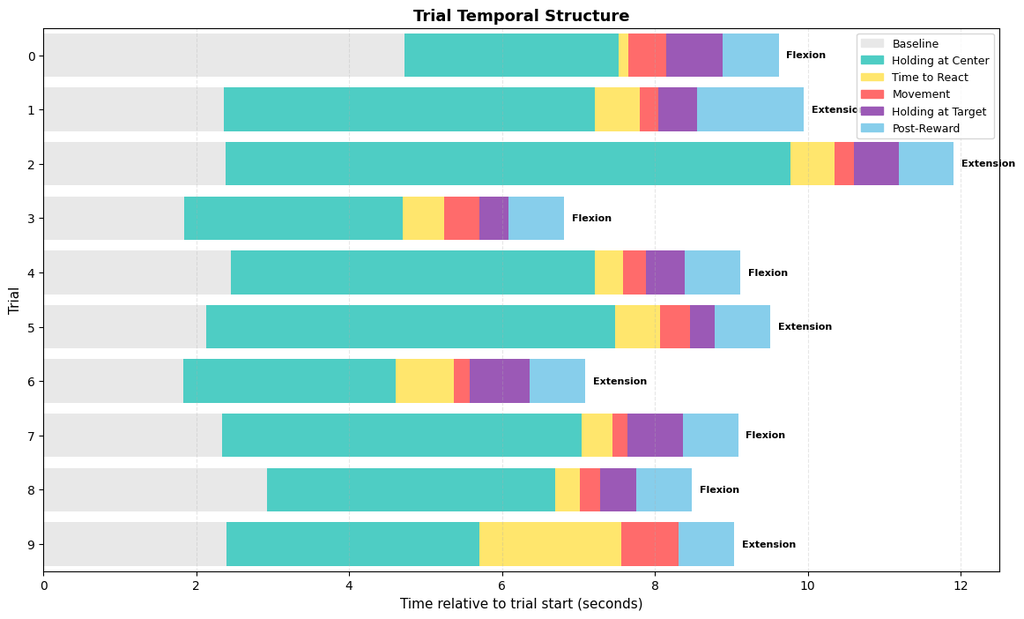

```python
from trial_structure_plot import plot_trial_structure

plot_trial_structure(trials_df, max_trials=10);
```

The visualization above shows the temporal structure of individual trials as horizontal stacked bars. Each row represents one trial, with colored segments indicating different task phases:

- **Baseline** (gray): Variable waiting period before the task begins
- **Holding at Center** (teal): The monkey maintains cursor position at the center target, waiting for the go cue
- **Time to React** (yellow): The interval between go cue (lateral target appearance) and cursor departure from the center zone
- **Movement** (coral): Active movement execution toward the peripheral target
- **Holding at Target** (purple): The monkey holds position at the target before reward delivery
- **Post-Reward** (sky blue): Brief period after reward before trial ends

### Derived Kinematic Measures

In addition to trial event times, the trials table includes derived kinematic parameters computed from post-hoc analysis of the elbow angle velocity trace. These measures characterize the movement itself:

| Column | Description | Units |
| --- | --- | --- |
| `derived_movement_onset_time` | Time when movement began (detected from velocity trace) | seconds |
| `derived_movement_end_time` | Time when movement ended (velocity returned to baseline) | seconds |
| `derived_peak_velocity` | Maximum angular velocity during the movement | degrees/second |
| `derived_peak_velocity_time` | Time of peak velocity | seconds |
| `derived_movement_amplitude` | Total angular displacement (end position - start position) | degrees |
| `derived_end_position` | Final elbow angle at movement end | degrees |

The "derived" prefix indicates these values were computed offline from kinematic analysis, not recorded directly during the experiment. The detection algorithm used position, velocity, and duration criteria (exact parameters not documented in source data).

```python
# Access derived kinematic measures
kinematic_columns = [
    'derived_movement_onset_time',
    'derived_movement_end_time',
    'derived_peak_velocity',
    'derived_peak_velocity_time',
    'derived_movement_amplitude',
    'derived_end_position',
    'movement_type'
]
trials_df[kinematic_columns].head(n=5)
```

| id | derived_movement_onset_time | derived_movement_end_time | derived_peak_velocity | derived_peak_velocity_time | derived_movement_amplitude | derived_end_position | movement_type |
| --- | --- | --- | --- | --- | --- | --- | --- |
| 0 | 7.816 | 8.150 | 53.880691 | 7.936 | 9.566975 | 16.760761 | flexion |
| 1 | 20.154 | 20.665 | 90.531582 | 20.440 | -27.823461 | -21.324000 | extension |
| 2 | 35.709 | 36.178 | 53.241705 | 35.969 | -12.224196 | -16.109740 | extension |
| 3 | 45.534 | 46.184 | 63.387040 | 45.714 | 19.073400 | 18.600860 | flexion |
| 4 | 57.832 | 58.183 | 73.071748 | 57.975 | 15.201504 | 21.514160 | flexion |

```python
# Compute commonly used derived measures
# Note: Some trials may have NaN values if kinematic detection failed

# Movement duration (from movement onset to movement end)
trials_df['movement_duration'] = (
    trials_df['derived_movement_end_time'] - trials_df['derived_movement_onset_time']
)

# Reaction time (from go cue to cursor departure)
trials_df['reaction_time'] = (
    trials_df['cursor_departure_time'] - trials_df['lateral_target_appearance_time']
)

# Filter to complete trials only
complete_trials = trials_df.dropna(subset=['derived_movement_end_time'])

print(f"Complete trials with kinematic data: {len(complete_trials)} / {len(trials_df)}")
print(f"\nMovement duration: {complete_trials['movement_duration'].mean()*1000:.0f} +/- {complete_trials['movement_duration'].std()*1000:.0f} ms")
print(f"Reaction time: {complete_trials['reaction_time'].mean()*1000:.0f} +/- {complete_trials['reaction_time'].std()*1000:.0f} ms")
print(f"Peak velocity: {complete_trials['derived_peak_velocity'].abs().mean():.1f} +/- {complete_trials['derived_peak_velocity'].abs().std():.1f} deg/s")
```

```
Complete trials with kinematic data: 77 / 80

Movement duration: 459 +/- 99 ms
Reaction time: 411 +/- 214 ms
Peak velocity: 79.0 +/- 19.7 deg/s
```

### Torque Perturbation Trials

A subset of trials included brief mechanical perturbations delivered via the torque motor during the center hold period. These perturbations caused rapid muscle stretch, allowing researchers to study proprioceptive responses in M1 neurons (see Pasquereau & Turner, 2013).

**Note:** Not all sessions include perturbation trials. Sessions without perturbations will have `torque_perturbation_type = "none"` for all trials and `torque_perturbation_onset_time = NaN`.

| Column | Description | Values |
| --- | --- | --- |
| `torque_perturbation_type` | Direction of the perturbation | `"flexion"`, `"extension"`, or `"none"` |
| `torque_perturbation_onset_time` | Time when perturbation was delivered | seconds (NaN if no perturbation) |

**Perturbation characteristics (when present):**

- Delivered 150-500 ms after center target appearance (during hold period)
- Brief torque pulse causing ~5-10 degree displacement
- Direction (flexion/extension) was independent of the upcoming movement direction
- Present in approximately 65% of trials in sessions that included perturbations

**Scientific purpose:** These trials enabled analysis of how M1 neurons respond to passive muscle stretch, separate from active movement. The muscle stretch study found that PTNs showed degraded directional selectivity to perturbations in the parkinsonian state.

```python
# Access torque perturbation data
perturbation_columns = ['torque_perturbation_type', 'torque_perturbation_onset_time', 'movement_type']
trials_df[perturbation_columns].head(n=10)
```

| id | torque_perturbation_type | torque_perturbation_onset_time | movement_type |
| --- | --- | --- | --- |
| 0 | none | NaN | flexion |
| 1 | flexion | 16.677 | extension |
| 2 | extension | 29.656 | extension |
| 3 | none | NaN | flexion |
| 4 | flexion | 54.447 | flexion |
| 5 | extension | 66.844 | extension |
| 6 | none | NaN | extension |
| 7 | flexion | 89.040 | flexion |
| 8 | extension | 101.724 | flexion |
| 9 | none | NaN | extension |

```python
# Analyze perturbation trial distribution
# Note: Not all sessions include perturbation trials. Sessions without perturbations
# will have torque_perturbation_type = "none" for all trials.

perturbation_counts = trials_df['torque_perturbation_type'].value_counts()
n_perturbation_trials = len(trials_df[trials_df['torque_perturbation_type'] != 'none'])

# Check if this session has perturbation data
if n_perturbation_trials == 0:
    print("This session does not include torque perturbation trials.")
    print("All trials have torque_perturbation_type = 'none'")
else:
    print(f"This session includes perturbation trials ({n_perturbation_trials} / {len(trials_df)} trials)\n")
    print("Perturbation trial counts:")
    for ptype, count in perturbation_counts.items():
        print(f"  {ptype}: {count} trials ({100*count/len(trials_df):.1f}%)")

    # Cross-tabulate perturbation direction vs movement direction
    print("\nPerturbation direction vs Movement direction:")
    print(trials_df.groupby(['torque_perturbation_type', 'movement_type']).size().unstack(fill_value=0))
```

```
This session includes perturbation trials (52 / 80 trials)

Perturbation trial counts:
  none: 28 trials (35.0%)
  flexion: 26 trials (32.5%)
  extension: 26 trials (32.5%)

Perturbation direction vs Movement direction:
movement_type             extension  flexion
torque_perturbation_type
extension                        13       13
flexion                          14       12
none                             13       15
```

### Isolation Monitoring Stimulation

In some recording sessions, single antidromic stimulation pulses were delivered early in certain trials to activate otherwise silent neurons and monitor unit isolation. This was particularly important for intratelencephalic-type (IT) cortical neurons (including corticostriatal neurons), which have very low spontaneous firing rates.

**Background:** Some neurons rarely spike spontaneously but can be reliably activated by antidromic stimulation from their projection target (striatum, thalamus, or cerebral peduncle). Delivering occasional stimulation pulses during recording confirmed that the unit remained well-isolated throughout the session.

| Column | Description | Values |
| --- | --- | --- |
| `isolation_monitoring_stim_time` | Time when stimulation pulse was delivered | seconds (NaN if no stimulation in that trial) |
| `isolation_monitoring_stim_site` | Anatomical target of the stimulation | `"Str"` (striatum), `"Thal"` (thalamus), `"Ped"` (peduncle), or empty string |

**Characteristics:**

- Stimulation pulses delivered ~244-245 ms after trial start (early in the baseline period)
- Present in approximately 43% of sessions (171 out of 400 session files)
- Most commonly targeting thalamus (117 sessions), followed by striatum (51 sessions)
- When present, stimulation typically delivered in a subset of trials within the session

**Note:** If you observe spike times that appear suspiciously constant across trials (~245-256 ms after trial start), these likely reflect antidromically-evoked spikes from isolation monitoring, not spontaneous activity.

```python
# Access isolation monitoring stimulation data (only trials with stimulation)
stim_columns = ['start_time', 'isolation_monitoring_stim_time', 'isolation_monitoring_stim_site']
stim_trials = trials_df[trials_df['isolation_monitoring_stim_time'].notna()]
stim_trials[stim_columns].head(n=10)
```

|  | start_time | isolation_monitoring_stim_time | isolation_monitoring_stim_site |
| --- | --- | --- | --- |
| id |  |  |  |

```python
# Check if this session has isolation monitoring stimulation
stim_trials = trials_df[trials_df['isolation_monitoring_stim_time'].notna()]
n_stim_trials = len(stim_trials)

if n_stim_trials == 0:
    print("This session does not include isolation monitoring stimulation.")
    print("All trials have isolation_monitoring_stim_time = NaN")
else:
    print(f"This session includes isolation monitoring stimulation ({n_stim_trials} / {len(trials_df)} trials)\n")

    # Get stimulation site (should be consistent within session)
    stim_site = stim_trials['isolation_monitoring_stim_site'].iloc[0]
    print(f"Stimulation site: {stim_site}")

    # Calculate timing relative to trial start
    stim_trials = stim_trials.copy()
    stim_trials['stim_time_relative'] = (
        stim_trials['isolation_monitoring_stim_time'] - stim_trials['start_time']
    )

    mean_stim_time = stim_trials['stim_time_relative'].mean() * 1000  # Convert to ms
    std_stim_time = stim_trials['stim_time_relative'].std() * 1000

    print(f"Stimulation timing: {mean_stim_time:.1f} +/- {std_stim_time:.1f} ms after trial start")
```

```
This session does not include isolation monitoring stimulation.
All trials have isolation_monitoring_stim_time = NaN
```

## Accessing Neurons/Units Spikes

The units table contains spike times and metadata for each recorded neuron. A key feature of this dataset is the classification of neurons into pyramidal tract neurons (PTNs) and corticostriatal neurons (CSNs) through antidromic stimulation.

```python
nwbfile.units
```

units (Units)

description: Autogenerated by NWBFile

waveform_unit: volts

**columns**

**neuron_projection_type**

Classification of layer 5 M1 neurons based on axonal projection target, determined through antidromic activation (electrical stimulation at target sites evoking backward-traveling spikes). Values: | 'pyramidal_tract_neuron': Large layer 5b neurons projecting to spinal cord via corticospinal tract, identified by cerebral peduncle stimulation (latency 0.6-2.5 ms) | 'corticostriatal_neuron': Intratelencephalic-type neurons projecting to posterolateral putamen, identified by striatal stimulation (latency 2.0-20 ms) | 'no_response': Antidromic stimulation attempted at one or both sites but neuron did not respond | 'not_tested': Antidromic identification was not performed for this neuron | 'pyramidal_tract_and_corticostriatal_neuron': Dual-projecting neuron responding to both sites | 'pyramidal_tract_and_thalamic_neuron': Neuron projecting to both pyramidal tract and thalamus | 'thalamic_projection_neuron': Neuron projecting to thalamus | 'subthalamic_projection_neuron': Neuron projecting to subthalamic nucleus | 'subthalamic_and_corticostriatal_neuron': Neuron projecting to both STN and striatum | 'subthalamic_and_thalamic_neuron': Neuron projecting to both STN and thalamus | 'pyramidal_tract_and_subthalamic_neuron': Neuron projecting to both pyramidal tract and STN

**antidromic_stimulation_sites**

Anatomical sites where antidromic stimulation was delivered via chronically implanted electrodes to identify neuron projection targets. Values: | 'cerebral_peduncle': Stimulation of corticospinal tract fibers to identify pyramidal tract neurons (100-400 uA, 0.2 ms biphasic pulses) | 'posterolateral_striatum': Stimulation of putamen to identify corticostriatal neurons (100-600 uA, 0.2 ms biphasic pulses) | 'cerebral_peduncle_and_posterolateral_striatum': Both stimulation sites were tested | 'subthalamic_nucleus': Stimulation of subthalamic nucleus (STN) | 'cerebral_peduncle_and_subthalamic_nucleus': Both peduncle and STN sites were tested | '': Empty string indicates antidromic testing was not attempted for this neuron

**antidromic_latency_ms**

Latency from stimulation to antidromic spike arrival at the recording electrode (in milliseconds) for the primary stimulation site. Reflects axon conduction velocity: PTNs have shorter latencies (0.6-2.5 ms) due to large, fast-conducting axons; CSNs have longer latencies (2.0-20 ms) due to smaller axons. Classification required fixed latency, high-frequency following (>200 Hz), and collision test confirmation.

**antidromic_threshold**

Minimum stimulation current (in microamps) required to reliably evoke antidromic activation at the primary stimulation site. Lower thresholds indicate electrode proximity to the axon or larger axon diameter. Typical ranges: 100-400 uA for cerebral peduncle, 100-600 uA for striatum.

**antidromic_latency_2_ms**

Antidromic response latency (in milliseconds) from secondary stimulation site, for neurons with dual projections (e.g., pyramidal_tract_and_corticostriatal_neuron). NaN if not applicable.

**antidromic_threshold_2**

Minimum stimulation current (in microamps) for antidromic activation at the secondary stimulation site. NaN if neuron does not have dual projections or secondary site was not tested.

**receptive_field_location**

Body region comprising this neuron's somatosensory receptive field, determined through qualitative sensorimotor examination. The experimenter manually manipulated the monkey's contralateral arm (passive joint movement, skin contact) while monitoring neural activity on an audio speaker. Values: | 'hand': Receptive field on the hand | 'wrist': Receptive field at the wrist joint | 'elbow': Receptive field at the elbow joint | 'forearm': Receptive field on the forearm | 'shoulder': Receptive field at the shoulder | 'finger': Receptive field on digit(s) | Combinations (e.g., 'hand / wrist'): Neuron responds to multiple body regions | 'no_response': Sensory testing performed but no response detected | 'not_tested': Sensory mapping not performed (limited recording time)

**receptive_field_stimulus**

Specific sensory stimulus or manipulation that activated this neuron during qualitative receptive field mapping (qualitative observer assessment, not quantified). Values: | 'ext': Joint extension (proprioceptive) | 'flex': Joint flexion (proprioceptive) | 'pron': Forearm pronation (proprioceptive) | 'sup': Forearm supination (proprioceptive) | 'light touch': Light tactile stimulation | 'palm probe': Pressure on palm | 'finger tap': Tapping on digit(s) | 'cut stim': Cutaneous (skin) stimulation | 'active': Firing during voluntary movement | 'active grip': Firing during voluntary grip | 'active hand': Firing during voluntary hand movement | Combinations (e.g., 'finger ext & elbow ext'): Multi-joint responses | 'NR': No response to any stimulus tested | 'NT': Sensory testing not performed | '': Testing data not recorded

**unit_name**

Unit identifier extracted from source MATLAB filename. When multiple well-isolated single units were recorded simultaneously during the same electrode penetration, each was saved separately. Most sessions contain a single unit. Values: | 1: First (or only) unit from this session, from file '{session}.1.mat' | 2: Second unit from this session, from file '{session}.2.mat'

**unit_also_in_session_id**

Cross-reference to another NWB session containing recordings from this same neuron, identified by the experimenter based on waveform similarity and recording location during the same electrode penetration. Empty string if this unit was only recorded in one session. Format matches session_id: {subject_id}++{fname}++{Pre|Post}MPTP++Depth{um}um++{YYYYMMDD}. This enables tracking individual neurons across multiple recording sessions or experimental conditions.

**is_post_mptp**

Boolean indicating parkinsonian state at time of recording. MPTP (1-methyl-4-phenyl-1,2,3,6-tetrahydropyridine) was administered once via unilateral left internal carotid artery injection (0.5 mg/kg), inducing selective dopaminergic cell death in the ipsilateral substantia nigra and producing stable contralateral hemiparkinsonian symptoms. Comparing pre/post recordings reveals how parkinsonism affects cortical motor encoding, particularly in pyramidal tract neurons. Values: | False: Pre-MPTP baseline recording (healthy motor control) | True: Post-MPTP recording after parkinsonian symptoms stabilized (bradykinesia, rigidity, movement initiation deficits)

**spike_times**

the spike times for each unit in seconds

**obs_intervals**

the observation intervals for each unit

**electrodes**

the electrodes that each spike unit came from

**table**

| id | neuron_projection_type | antidromic_stimulation_sites | antidromic_latency_ms | antidromic_threshold | antidromic_latency_2_ms | antidromic_threshold_2 | receptive_field_location | receptive_field_stimulus | unit_name | unit_also_in_session_id | is_post_mptp | spike_times | obs_intervals | electrodes |
| --- | --- | --- | --- | --- | --- | --- | --- | --- | --- | --- | --- | --- | --- | --- |
| 0 | pyramidal_tract_neuron | cerebral_peduncle | 1.80 | 550.0 | NaN | NaN | no_response |  | 1 | V++v5812++PostMPTP++Depth18300um++20000331 | True | [0.248, 0.524, 0.586, 0.653, 0.952, 1.216, 1.368, 1.431, 1.582, 1.638, 1.683, 1.73, 1.773, 1.829, 2.074, 2.77, 4.469, 4.559, 4.601, 4.79, 5.628, 5.732, 5.868, 5.938, 6.029, 6.096, 6.391, 6.438, 6.482,… | [[0.0, 9.619], [12.619, 22.570999999999998], [25.570999999999998, 37.483], [40.483, 47.296], [50.29599999999999, 59.41199999999999], [62.41199999999999, 71.92099999999999], [74.92099999999999, 82.0089… | [0] |
| 1 | pyramidal_tract_neuron |  | 1.85 | 360.0 | NaN | NaN | no_response |  | 2 |  | True | [0.025, 0.078, 0.13, 0.172, 0.212, 0.26, 0.285, 0.318, 0.389, 0.428, 0.491, 0.515, 0.618, 0.638, 0.714, 0.731, 0.78, 0.875, 0.895, 0.94, 0.974, 0.977, 1.07, 1.13, 1.15, 1.182, 1.208, 1.242, 1.274, 1.3… | [[0.0, 9.619], [12.619, 22.570999999999998], [25.570999999999998, 37.483], [40.483, 47.296], [50.29599999999999, 59.41199999999999], [62.41199999999999, 71.92099999999999], [74.92099999999999, 82.0089… | [0] |

Like the trials table, the units table is a DynamicTable that can be converted to a pandas DataFrame for easier exploration and analysis.

```python
units_df = nwbfile.units.to_dataframe()
units_df
```

| id | neuron_projection_type | antidromic_stimulation_sites | antidromic_latency_ms | antidromic_threshold | antidromic_latency_2_ms | antidromic_threshold_2 | receptive_field_location | receptive_field_stimulus | unit_name | unit_also_in_session_id | is_post_mptp | spike_times | obs_intervals | electrodes |
| --- | --- | --- | --- | --- | --- | --- | --- | --- | --- | --- | --- | --- | --- | --- |
| 0 | pyramidal_tract_neuron | cerebral_peduncle | 1.80 | 550.0 | NaN | NaN | no_response |  | 1 | V++v5812++PostMPTP++Depth18300um++20000331 | True | [0.248, 0.524, 0.586, 0.653, 0.952, 1.216, 1.3... | [[0.0, 9.619], [12.619, 22.570999999999998], [... | location \ i... |
| 1 | pyramidal_tract_neuron |  | 1.85 | 360.0 | NaN | NaN | no_response |  | 2 |  | True | [0.025, 0.078, 0.13, 0.172, 0.212, 0.26, 0.285... | [[0.0, 9.619], [12.619, 22.570999999999998], [... | location \ i... |

### Accessing Spike Times

Each unit's spike times are stored as an array of timestamps (in seconds) relative to session start. You can access them by unit index.

```python
# Accessing spike times
for unit_id in range(len(units_df)):
    spike_times = nwbfile.units['spike_times'][unit_id]

    print(f"Unit {unit_id}:")
    print(f"  Total spikes: {len(spike_times)}")
    print(f"  Recording duration: {spike_times[-1] - spike_times[0]:.2f} s")
    print(f"  Mean firing rate: {len(spike_times) / (spike_times[-1] - spike_times[0]):.2f} Hz")
    print()
```

```
Unit 0:
  Total spikes: 6933
  Recording duration: 930.05 s
  Mean firing rate: 7.45 Hz

Unit 1:
  Total spikes: 10451
  Recording duration: 930.08 s
  Mean firing rate: 11.24 Hz
```

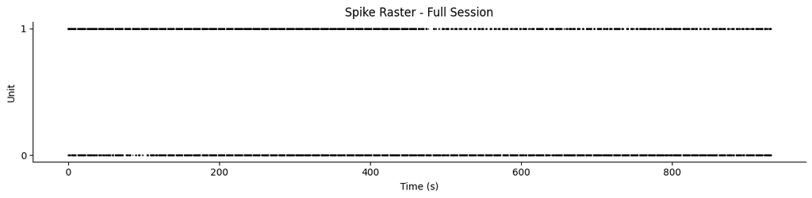

```python
# Simple spike raster plot
import matplotlib.pyplot as plt
import numpy as np

fig, ax = plt.subplots(figsize=(12, 3))

for unit_id in range(len(units_df)):
    spike_times = nwbfile.units['spike_times'][unit_id]
    ax.scatter(spike_times, np.ones_like(spike_times) * unit_id,
               s=0.5, color='black', alpha=0.6)

ax.set_xlabel('Time (s)')
ax.set_ylabel('Unit')
ax.set_yticks(range(len(units_df)))
ax.set_title('Spike Raster - Full Session')
ax.spines['top'].set_visible(False)
ax.spines['right'].set_visible(False)
plt.tight_layout()
plt.show()
```

### Understanding Observation Intervals (Trialized Data)

Looking at the raster above, you might assume spikes were recorded continuously throughout the session. However, this dataset was converted from **trial-based MATLAB files** where each trial's data was stored separately. The trials have been concatenated into a continuous timeline with **3-second artificial gaps** between them.

**Important**: The inter-trial gaps are placeholders - no data was actually recorded during these periods. Spikes appear continuous because the gaps are relatively short compared to the full session duration.

To see this structure clearly, let's zoom in on the first few trials:

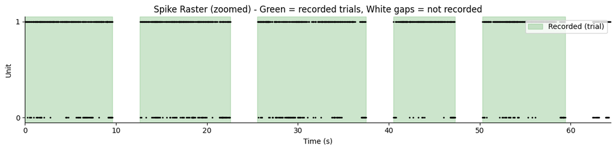

```
Notice the ~3-second white gaps between green regions - these are artificial placeholders.
No spikes occur in the gaps because no data was recorded during inter-trial intervals.
```

```python
# Zoomed spike raster showing observation intervals (trials) vs gaps
# Green = data was recorded, White = artificial gap (no data recorded)
obs_intervals = nwbfile.units.get_unit_obs_intervals(0)

# Zoom to first 5 trials to clearly see the structure
n_trials_to_show = 5
xlim_end = obs_intervals[n_trials_to_show - 1, 1] + 5  # Include a bit after last shown trial

fig, ax = plt.subplots(figsize=(12, 3))

# Shade observation intervals (when data was actually recorded)
for i, (start, stop) in enumerate(obs_intervals[:n_trials_to_show]):
    label = 'Recorded (trial)' if i == 0 else '_nolegend_'
    ax.axvspan(start, stop, alpha=0.2, color='green', label=label)

# Plot spikes
for unit_id in range(len(units_df)):
    spike_times = nwbfile.units['spike_times'][unit_id]
    mask = spike_times < xlim_end
    ax.scatter(spike_times[mask], np.ones(mask.sum()) * unit_id,
               s=2, color='black', alpha=0.8)

ax.set_xlim(0, xlim_end)
ax.set_xlabel('Time (s)')
ax.set_ylabel('Unit')
ax.set_yticks(range(len(units_df)))
ax.set_title('Spike Raster (zoomed) - Green = recorded trials, White gaps = not recorded')
ax.legend(loc='upper right')
ax.spines['top'].set_visible(False)
ax.spines['right'].set_visible(False)
plt.tight_layout()
plt.show()

print(f"Notice the ~3-second white gaps between green regions - these are artificial placeholders.")
print(f"No spikes occur in the gaps because no data was recorded during inter-trial intervals.")
```

Each unit has an `obs_intervals` column that specifies exactly when it was being recorded (i.e., during trials only). This is critical for accurate analysis:

- Firing rates should use observed time, not total session time
- ISI calculations should not span trial boundaries

```python
# Accessing obs_intervals and computing correct firing rates
obs_intervals = nwbfile.units.get_unit_obs_intervals(0)
print(f"Unit 0 was observed during {len(obs_intervals)} trial windows")
print(f"\nFirst 3 observation windows (start, stop in seconds):")
for i, (start, stop) in enumerate(obs_intervals[:3]):
    print(f"  Trial {i}: {start:.2f}s - {stop:.2f}s (duration: {stop-start:.2f}s)")

# Calculate CORRECT firing rate using only observed time
spike_times = nwbfile.units.get_unit_spike_times(0)
total_observed_time = sum(stop - start for start, stop in obs_intervals)
session_duration = obs_intervals[-1, 1] - obs_intervals[0, 0]

correct_rate = len(spike_times) / total_observed_time
naive_rate = len(spike_times) / session_duration

print(f"\nFiring rate comparison:")
print(f"  Correct (using obs_intervals): {correct_rate:.2f} Hz")
print(f"  Naive (using session duration): {naive_rate:.2f} Hz")
print(f"  Difference: {100*(correct_rate - naive_rate)/correct_rate:.1f}% underestimate if gaps not excluded")
```

```
Unit 0 was observed during 80 trial windows

First 3 observation windows (start, stop in seconds):
  Trial 0: 0.00s - 9.62s (duration: 9.62s)
  Trial 1: 12.62s - 22.57s (duration: 9.95s)
  Trial 2: 25.57s - 37.48s (duration: 11.91s)

Firing rate comparison:
  Correct (using obs_intervals): 10.00 Hz
  Naive (using session duration): 7.45 Hz
  Difference: 25.5% underestimate if gaps not excluded
```

### Invalid Times Table (For Continuous Signals)

While `obs_intervals` annotates when each **unit** was observable, the NWB file also includes an `invalid_times` table that marks the inter-trial gaps at the **session level**. This is useful for filtering continuous signals like LFP, EMG, and kinematics.

**Relationship between the two:**

- `obs_intervals` (per-unit): Specifies when spikes could occur. Use for spike train analysis.
- `invalid_times` (session-wide): Specifies time periods to exclude. Use for continuous signals.

Both describe the same underlying structure (trialized data with artificial gaps). The gaps listed in `invalid_times` correspond exactly to the periods *between* the `obs_intervals`.

```python
# Access the invalid_times table
invalid_times_df = nwbfile.invalid_times.to_dataframe()
invalid_times_df.head(5)
```

| id | start_time | stop_time | tags |
| --- | --- | --- | --- |
| 0 | 9.619 | 12.619 | [artificial_inter_trial_gap, not_recorded] |
| 1 | 22.571 | 25.571 | [artificial_inter_trial_gap, not_recorded] |
| 2 | 37.483 | 40.483 | [artificial_inter_trial_gap, not_recorded] |
| 3 | 47.296 | 50.296 | [artificial_inter_trial_gap, not_recorded] |
| 4 | 59.412 | 62.412 | [artificial_inter_trial_gap, not_recorded] |

### Neuron Projection Type (Cell Classification)

Each neuron in this dataset was classified by its axonal projection target using antidromic stimulation. This classification allows you to analyze PTNs and CSNs separately.

| Column | Description | Values |
| --- | --- | --- |
| `neuron_projection_type` | Classification based on antidromic response | `"pyramidal_tract_neuron"`, `"corticostriatal_neuron"`, `"no_response"`, `"not_tested"` |

**Cell type definitions:**

- **Pyramidal Tract Neurons (PTNs)**: Large layer 5b neurons whose axons descend through the cerebral peduncle to the spinal cord. These are the primary motor output neurons that send commands directly to spinal motor circuits. Identified by antidromic activation from the cerebral peduncle.
- **Corticostriatal Neurons (CSNs)**: Intratelencephalic-type layer 5 neurons projecting to the striatum (putamen). These provide cortical input to basal ganglia circuits involved in action selection. Identified by antidromic activation from the posterolateral putamen.
- **No Response**: Neuron was tested but did not respond antidromically to any stimulation site.
- **Not Tested**: Antidromic testing was not performed for this neuron.

```python
# Examine neuron classification
classification_columns = ['neuron_projection_type', 'is_post_mptp', 'unit_name']
units_df[classification_columns]
```

| id | neuron_projection_type | is_post_mptp | unit_name |
| --- | --- | --- | --- |
| 0 | pyramidal_tract_neuron | True | 1 |
| 1 | pyramidal_tract_neuron | True | 2 |

### Antidromic Identification Parameters

For neurons that responded antidromically, the units table includes parameters from the identification protocol:

[output not shown]

**Latency interpretation:**

- **PTNs (peduncle stimulation)**: 0.6-2.5 ms latencies indicate large-diameter, fast-conducting axons (~20-50 m/s)
- **CSNs (putamen stimulation)**: 2-20 ms latencies indicate smaller, slower-conducting axons typical of intratelencephalic neurons

```python
# Examine antidromic identification parameters
antidromic_columns = [
    'neuron_projection_type',
    'antidromic_stimulation_sites',
    'antidromic_latency_ms',
    'antidromic_threshold'
]
units_df[antidromic_columns]
```

| id | neuron_projection_type | antidromic_stimulation_sites | antidromic_latency_ms | antidromic_threshold |
| --- | --- | --- | --- | --- |
| 0 | pyramidal_tract_neuron | cerebral_peduncle | 1.80 | 550.0 |
| 1 | pyramidal_tract_neuron |  | 1.85 | 360.0 |

### Receptive Field Properties

During recording sessions, experimenters performed qualitative sensory testing to characterize each neuron's receptive field. This involved manually manipulating the monkey's arm while listening to the neural activity.

| Column | Description | Values |
| --- | --- | --- |
| `receptive_field_location` | Body region(s) comprising the receptive field | `"hand"`, `"wrist"`, `"elbow"`, `"shoulder"`, combinations, `"no_response"`, or `"not_tested"` |
| `receptive_field_stimulus` | Type of manipulation that activated the neuron | `"ext"`, `"flex"`, `"pron"`, `"light touch"`, `"active grip"`, etc. |

**Common abbreviations in `receptive_field_stimulus`:**

- `ext` = extension, `flex` = flexion
- `pron` = pronation, `sup` = supination
- `cut` = cutaneous (skin stimulation)
- `NR` = no response, `NT` = not tested

**Interpretation:**

- Most neurons responded to distal arm regions (hand, wrist, fingers), consistent with recording in arm-related M1
- Multiple regions separated by `/` indicate neurons with broad receptive fields
- Sensory characterization is independent of but complementary to antidromic cell-type identification

```python
# Examine receptive field properties
rf_columns = ['receptive_field_location', 'receptive_field_stimulus', 'neuron_projection_type']
units_df[rf_columns]
```

| id | receptive_field_location | receptive_field_stimulus | neuron_projection_type |
| --- | --- | --- | --- |
| 0 | no_response |  | pyramidal_tract_neuron |
| 1 | no_response |  | pyramidal_tract_neuron |

```python
# Examine receptive field properties (units with responses)
rf_columns = ['receptive_field_location', 'receptive_field_stimulus', 'neuron_projection_type']
units_with_rf = units_df[~units_df['receptive_field_location'].isin(['not_tested', 'no_response'])]

if len(units_with_rf) > 0:
    print(f"Units with receptive field responses: {len(units_with_rf)} / {len(units_df)}")
    display(units_with_rf[rf_columns])
else:
    print("No units in this session have documented receptive field responses.")
    print("Showing all units:")
    display(units_df[rf_columns])
```

```
No units in this session have documented receptive field responses.
Showing all units:
```

| id | receptive_field_location | receptive_field_stimulus | neuron_projection_type |
| --- | --- | --- | --- |
| 0 | no_response |  | pyramidal_tract_neuron |
| 1 | no_response |  | pyramidal_tract_neuron |

### Additional Unit Metadata

| Column | Description | Values |
| --- | --- | --- |
| `is_post_mptp` | Whether recording was obtained after MPTP treatment | `True` or `False` |
| `unit_also_in_session_id` | Session ID if this unit also appears in another file | session ID string or empty |

**Note on `unit_also_in_session_id`:** Some neurons were recorded across multiple electrode depths within the same penetration. When a unit appears in multiple session files, this column contains the session ID of the related file. This allows linking the same neuron across different recording depths.

### Electrodes Table

The electrodes table contains metadata for the recording electrode, including chamber-relative coordinates that allow mapping recordings to anatomical locations in M1.

| Column | Description | Units/Values |
| --- | --- | --- |
| `chamber_grid_ap_mm` | Anterior-posterior position in chamber grid | mm (positive = posterior, range: -7 to 0) |
| `chamber_grid_ml_mm` | Medial-lateral position in chamber grid | mm (positive = right, range: -6 to -2) |
| `chamber_insertion_depth_mm` | Depth from chamber surface | mm (range: 8.4-27.6) |

**Recording electrode:** Glass-coated platinum-iridium microelectrode lowered through the recording chamber into M1. The chamber coordinates allow reconstructing electrode positions relative to the cortical sulcal pattern.

**Coordinate system:** Chamber-relative coordinates specific to each animal's implanted recording chamber. The chamber was positioned over left M1 at 35 degrees to the coronal plane. These are NOT standard stereotaxic atlas coordinates.

**Note:** Stimulation electrodes (for antidromic identification) are represented as separate devices, not in the electrodes table. See `nwbfile.devices` for stimulation electrode descriptions.

```python
# Access electrodes table
electrodes_df = nwbfile.electrodes.to_dataframe()
electrodes_df
```

| id | location | group | chamber_grid_ap_mm | chamber_grid_ml_mm | chamber_insertion_depth_mm | icms_effect | icms_threshold_uA | group_name | x | y | z | imp | filtering |
| --- | --- | --- | --- | --- | --- | --- | --- | --- | --- | --- | --- | --- | --- |
| 0 | agranular frontal area F1 (or area 4) | ElectrodeGroupMicroelectrodeRecording pynwb.ec... | -6 | -2.5 | 18.3 | not_tested | NaN | ElectrodeGroupMicroelectrodeRecording | -13472.805 | -30783.554 | -18067.467 | NaN | 0.3-10kHz bandpass for spikes, 1-100Hz for LFP... |

```python
# Get recording electrode coordinates
recording_electrode = electrodes_df.iloc[0]

print("Recording electrode location:")
print(f"  Chamber A/P: {recording_electrode['chamber_grid_ap_mm']:.1f} mm")
print(f"  Chamber M/L: {recording_electrode['chamber_grid_ml_mm']:.1f} mm")
print(f"  Depth: {recording_electrode['chamber_insertion_depth_mm']:.2f} mm")
```

```
Recording electrode location:
  Chamber A/P: -6.0 mm
  Chamber M/L: -2.5 mm
  Depth: 18.30 mm
```

## Analog Signals (Kinematics, EMG, LFP)

The acquisition container holds continuous time series data recorded during the task. These signals are concatenated across trials with the same timestamps as the trials table.

```python
nwbfile.acquisition
```

acquisition

**EMGDeltoidPosterior (TimeSeries)**

EMGDeltoidPosterior (TimeSeries)

resolution: -1.0

comments: Data are uncalibrated A/D converter values (centered ~2048, consistent with 12-bit digitization). No voltage calibration factor is available. Values represent relative muscle activation magnitude.

description: Preprocessed EMG from Posterior deltoid - shoulder extensor and external rotator. Recording: chronically-implanted Teflon-insulated multistranded stainless steel wire electrodes. Signal processing: differentially amplified (gain=10,000), bandpass filtered (20 Hz - 5 kHz), full-wave rectified, sample-hold integrated (10 ms integration interval), then digitized.

conversion: 1.0

offset: 0.0

unit: a.u.

**data**

HDF5 dataset

| Data type | float64 |
| --- | --- |
| Shape | (692972,) |
| Array size | 5.29 MiB |
| Chunk shape | (692972,) |
| Compression | gzip |
| Compression opts | 4 |
| Uncompressed size (bytes) | 5543776 |
| Compressed size (bytes) | 3845682 |
| Compression ratio | 1.441558610410325 |

**timestamps**

HDF5 dataset

| Data type | float64 |
| --- | --- |
| Shape | (692972,) |
| Array size | 5.29 MiB |
| Chunk shape | (692972,) |
| Compression | gzip |
| Compression opts | 4 |
| Uncompressed size (bytes) | 5543776 |
| Compressed size (bytes) | 4035421 |
| Compression ratio | 1.3737788448838424 |

timestamps_unit: seconds

interval: 1

**EMGTrapezius (TimeSeries)**

EMGTrapezius (TimeSeries)

resolution: -1.0

comments: Data are uncalibrated A/D converter values (centered ~2048, consistent with 12-bit digitization). No voltage calibration factor is available. Values represent relative muscle activation magnitude.

description: Preprocessed EMG from Trapezius - shoulder and scapula stabilizer. Recording: chronically-implanted Teflon-insulated multistranded stainless steel wire electrodes. Signal processing: differentially amplified (gain=10,000), bandpass filtered (20 Hz - 5 kHz), full-wave rectified, sample-hold integrated (10 ms integration interval), then digitized.

conversion: 1.0

offset: 0.0

unit: a.u.

**data**

HDF5 dataset

| Data type | float64 |
| --- | --- |
| Shape | (692972,) |
| Array size | 5.29 MiB |
| Chunk shape | (692972,) |
| Compression | gzip |
| Compression opts | 4 |
| Uncompressed size (bytes) | 5543776 |
| Compressed size (bytes) | 3746068 |
| Compression ratio | 1.4798919827403025 |

**timestamps**

HDF5 dataset

| Data type | float64 |
| --- | --- |
| Shape | (692972,) |
| Array size | 5.29 MiB |
| Chunk shape | (692972,) |
| Compression | gzip |
| Compression opts | 4 |
| Uncompressed size (bytes) | 5543776 |
| Compressed size (bytes) | 4035421 |
| Compression ratio | 1.3737788448838424 |

timestamps_unit: seconds

interval: 1

**EMGTricepsLateralis (TimeSeries)**

EMGTricepsLateralis (TimeSeries)

resolution: -1.0

comments: Data are uncalibrated A/D converter values (centered ~2048, consistent with 12-bit digitization). No voltage calibration factor is available. Values represent relative muscle activation magnitude.

description: Preprocessed EMG from Triceps lateralis (lateral head) - elbow extensor. Recording: chronically-implanted Teflon-insulated multistranded stainless steel wire electrodes. Signal processing: differentially amplified (gain=10,000), bandpass filtered (20 Hz - 5 kHz), full-wave rectified, sample-hold integrated (10 ms integration interval), then digitized.

conversion: 1.0

offset: 0.0

unit: a.u.

**data**

HDF5 dataset

| Data type | float64 |
| --- | --- |
| Shape | (692972,) |
| Array size | 5.29 MiB |
| Chunk shape | (692972,) |
| Compression | gzip |
| Compression opts | 4 |
| Uncompressed size (bytes) | 5543776 |
| Compressed size (bytes) | 3493671 |
| Compression ratio | 1.586805397531708 |

**timestamps**

HDF5 dataset

| Data type | float64 |
| --- | --- |
| Shape | (692972,) |
| Array size | 5.29 MiB |
| Chunk shape | (692972,) |
| Compression | gzip |
| Compression opts | 4 |
| Uncompressed size (bytes) | 5543776 |
| Compressed size (bytes) | 4035421 |
| Compression ratio | 1.3737788448838424 |

timestamps_unit: seconds

interval: 1

**EMGTricepsLongus1 (TimeSeries)**

EMGTricepsLongus1 (TimeSeries)

resolution: -1.0

comments: Data are uncalibrated A/D converter values (centered ~2048, consistent with 12-bit digitization). No voltage calibration factor is available. Values represent relative muscle activation magnitude.

description: Preprocessed EMG from Triceps longus (long head) - elbow extensor. Channel 1 of 2 separate electrodes placed in different compartments of triceps longus (long head). The numeric suffix reflects channel order in the source mapping, not a known anatomical position. Inferred compartment: distal (provisional). Empirical analysis across ~280 Venus sessions, using cross-correlation lead-lag and posterior-deltoid correlation between the two triceps longus channels (see scripts/triceps_compartment_analysis/), suggests this channel is the more distal of the two compartments. The assignment is not confirmed by the original investigators and is intentionally not encoded in the channel name. Recording: chronically-implanted Teflon-insulated multistranded stainless steel wire electrodes. Signal processing: differentially amplified (gain=10,000), bandpass filtered (20 Hz - 5 kHz), full-wave rectified, sample-hold integrated (10 ms integration interval), then digitized.

conversion: 1.0

offset: 0.0

unit: a.u.

**data**

HDF5 dataset

| Data type | float64 |
| --- | --- |
| Shape | (692972,) |
| Array size | 5.29 MiB |
| Chunk shape | (692972,) |
| Compression | gzip |
| Compression opts | 4 |
| Uncompressed size (bytes) | 5543776 |
| Compressed size (bytes) | 3431351 |
| Compression ratio | 1.6156248661241592 |

**timestamps**

HDF5 dataset

| Data type | float64 |
| --- | --- |
| Shape | (692972,) |
| Array size | 5.29 MiB |
| Chunk shape | (692972,) |
| Compression | gzip |
| Compression opts | 4 |
| Uncompressed size (bytes) | 5543776 |
| Compressed size (bytes) | 4035421 |
| Compression ratio | 1.3737788448838424 |

timestamps_unit: seconds

interval: 1

**EMGTricepsLongus2 (TimeSeries)**

EMGTricepsLongus2 (TimeSeries)

resolution: -1.0

comments: Data are uncalibrated A/D converter values (centered ~2048, consistent with 12-bit digitization). No voltage calibration factor is available. Values represent relative muscle activation magnitude.

description: Preprocessed EMG from Triceps longus (long head) - elbow extensor. Channel 2 of 2 separate electrodes placed in different compartments of triceps longus (long head). The numeric suffix reflects channel order in the source mapping, not a known anatomical position. Inferred compartment: proximal (provisional). Empirical analysis across ~280 Venus sessions, using cross-correlation lead-lag and posterior-deltoid correlation between the two triceps longus channels (see scripts/triceps_compartment_analysis/), suggests this channel is the more proximal of the two compartments. The assignment is not confirmed by the original investigators and is intentionally not encoded in the channel name. Recording: chronically-implanted Teflon-insulated multistranded stainless steel wire electrodes. Signal processing: differentially amplified (gain=10,000), bandpass filtered (20 Hz - 5 kHz), full-wave rectified, sample-hold integrated (10 ms integration interval), then digitized.

conversion: 1.0

offset: 0.0

unit: a.u.

**data**

HDF5 dataset

| Data type | float64 |
| --- | --- |
| Shape | (692972,) |
| Array size | 5.29 MiB |
| Chunk shape | (692972,) |
| Compression | gzip |
| Compression opts | 4 |
| Uncompressed size (bytes) | 5543776 |
| Compressed size (bytes) | 3323797 |
| Compression ratio | 1.667904508006957 |

**timestamps**

HDF5 dataset

| Data type | float64 |
| --- | --- |
| Shape | (692972,) |
| Array size | 5.29 MiB |
| Chunk shape | (692972,) |
| Compression | gzip |
| Compression opts | 4 |
| Uncompressed size (bytes) | 5543776 |
| Compressed size (bytes) | 4035421 |
| Compression ratio | 1.3737788448838424 |

timestamps_unit: seconds

interval: 1

**ElbowAngle (SpatialSeries)**

ElbowAngle (SpatialSeries)

resolution: -1.0

comments: no comments

description: Raw manipulandum angle from sensor during visuomotor flexion/extension task

conversion: 1.0

offset: 0.0

unit: degrees

**data**

HDF5 dataset

| Data type | float64 |
| --- | --- |
| Shape | (692972, 1) |
| Array size | 5.29 MiB |
| Chunk shape | (692972, 1) |
| Compression | gzip |
| Compression opts | 4 |
| Uncompressed size (bytes) | 5543776 |
| Compressed size (bytes) | 2130872 |
| Compression ratio | 2.6016466498222326 |

**timestamps**

HDF5 dataset

| Data type | float64 |
| --- | --- |
| Shape | (692972,) |
| Array size | 5.29 MiB |
| Chunk shape | (692972,) |
| Compression | gzip |
| Compression opts | 4 |
| Uncompressed size (bytes) | 5543776 |
| Compressed size (bytes) | 4035421 |
| Compression ratio | 1.3737788448838424 |

timestamps_unit: seconds

interval: 1

reference_frame: Anatomical flexion/extension axis, 0 degrees = neutral position, positive = extension

**ElbowTorque (TimeSeries)**

ElbowTorque (TimeSeries)

resolution: -1.0

comments: no comments

description: Commands sent to torque controller during visuomotor task

conversion: 1.0

offset: 0.0

unit: arbitrary

**data**

HDF5 dataset

| Data type | float64 |
| --- | --- |
| Shape | (692972,) |
| Array size | 5.29 MiB |
| Chunk shape | (692972,) |
| Compression | gzip |
| Compression opts | 4 |
| Uncompressed size (bytes) | 5543776 |
| Compressed size (bytes) | 679707 |
| Compression ratio | 8.1561260955088 |

**timestamps**

HDF5 dataset

| Data type | float64 |
| --- | --- |
| Shape | (692972,) |
| Array size | 5.29 MiB |
| Chunk shape | (692972,) |
| Compression | gzip |
| Compression opts | 4 |
| Uncompressed size (bytes) | 5543776 |
| Compressed size (bytes) | 4035421 |
| Compression ratio | 1.3737788448838424 |

timestamps_unit: seconds

interval: 1

### Manipulandum Signals (Kinematics)

The monkey controlled a cursor by rotating a manipulandum with their elbow. Three kinematic signals are recorded:

| Signal | Location | Description | Units |
| --- | --- | --- | --- |
| `ElbowAngle` | `acquisition` | Elbow joint angle | degrees |
| `ElbowVelocity` | `processing['behavior']` | Angular velocity (derivative of position) | degrees/second |
| `ElbowTorque` | `acquisition` | Torque command sent to the motor | arbitrary units |

```python
# Access kinematic signals
elbow_angle = nwbfile.acquisition['ElbowAngle']
elbow_velocity = nwbfile.processing['behavior']['ElbowVelocity']

print(f"Elbow Angle: {elbow_angle.data.shape[0]} samples")
print(f"Elbow Velocity: {elbow_velocity.data.shape[0]} samples")

# Get data and timestamps
angle_data = elbow_angle.data[:]
velocity_data = elbow_velocity.data[:]
timestamps = elbow_angle.timestamps[:]

print(f"Duration: {timestamps[-1] - timestamps[0]:.1f} s")
```

```
Elbow Angle: 692972 samples
Elbow Velocity: 692972 samples
```

```
Duration: 930.0 s
```

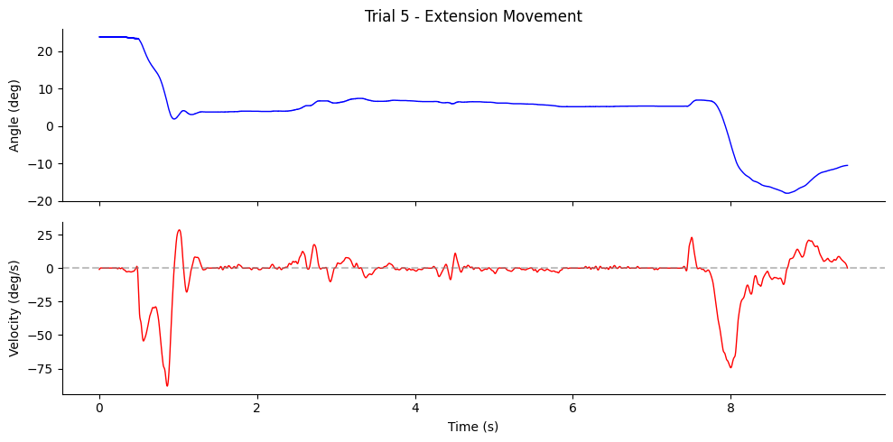

```python
# Plot kinematic signals for a single trial
trial_idx = 5
trial = trials_df.iloc[trial_idx]
t_start, t_stop = trial['start_time'], trial['stop_time']

# Extract trial segment using timestamps
mask = (timestamps >= t_start) & (timestamps <= t_stop)
trial_time = timestamps[mask] - t_start  # Relative to trial start

fig, axes = plt.subplots(2, 1, figsize=(10, 5), sharex=True)

axes[0].plot(trial_time, angle_data[mask], 'b-', linewidth=1)
axes[0].set_ylabel('Angle (deg)')
axes[0].set_title(f'Trial {trial_idx} - {trial["movement_type"].capitalize()} Movement')
axes[0].spines['top'].set_visible(False)
axes[0].spines['right'].set_visible(False)

axes[1].plot(trial_time, velocity_data[mask], 'r-', linewidth=1)
axes[1].set_ylabel('Velocity (deg/s)')
axes[1].set_xlabel('Time (s)')
axes[1].axhline(0, color='gray', linestyle='--', alpha=0.5)
axes[1].spines['top'].set_visible(False)
axes[1].spines['right'].set_visible(False)

plt.tight_layout()
plt.show()
```

### EMG Signals

Electromyography (EMG) recordings from arm muscles are available in some sessions. Each muscle has its own TimeSeries named `EMG{MuscleName}`.

**Note:** Not all sessions include EMG data. Check `nwbfile.acquisition` for available signals.

```python
# Find EMG signals in acquisition
emg_signals = {name: ts for name, ts in nwbfile.acquisition.items() if name.startswith('EMG')}

if emg_signals:
    print(f"EMG signals available ({len(emg_signals)} muscles):")
    for name, ts in emg_signals.items():
        muscle_name = name.replace('EMG', '')
        print(f"  {muscle_name}: {ts.description}")
else:
    print("No EMG signals in this session.")
```

```
EMG signals available (5 muscles):
  DeltoidPosterior: Preprocessed EMG from Posterior deltoid - shoulder extensor and external rotator. Recording: chronically-implanted Teflon-insulated multistranded stainless steel wire electrodes. Signal processing: differentially amplified (gain=10,000), bandpass filtered (20 Hz - 5 kHz), full-wa…
  Trapezius: Preprocessed EMG from Trapezius - shoulder and scapula stabilizer. Recording: chronically-implanted Teflon-insulated multistranded stainless steel wire electrodes. Signal processing: differentially amplified (gain=10,000), bandpass filtered (20 Hz - 5 kHz), full-wave rectified, sample-h…
  TricepsLateralis: Preprocessed EMG from Triceps lateralis (lateral head) - elbow extensor. Recording: chronically-implanted Teflon-insulated multistranded stainless steel wire electrodes. Signal processing: differentially amplified (gain=10,000), bandpass filtered (20 Hz - 5 kHz), full-wave rectif…
  TricepsLongus1: Preprocessed EMG from Triceps longus (long head) - elbow extensor. Channel 1 of 2 separate electrodes placed in different compartments of triceps longus (long head). The numeric suffix reflects channel order in the source mapping, not a known anatomical position. Inferred compartme…
  TricepsLongus2: Preprocessed EMG from Triceps longus (long head) - elbow extensor. Channel 2 of 2 separate electrodes placed in different compartments of triceps longus (long head). The numeric suffix reflects channel order in the source mapping, not a known anatomical position. Inferred compartme…
```

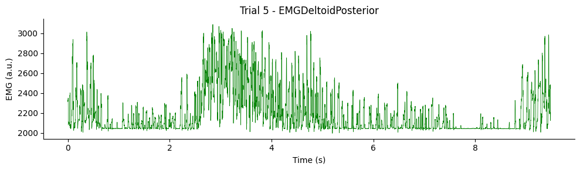

```python
# Plot EMG signals for a single trial (if available)
if emg_signals:
    trial_idx = 5
    trial = trials_df.iloc[trial_idx]
    t_start, t_stop = trial['start_time'], trial['stop_time']

    # Get first EMG signal for plotting
    emg_name = list(emg_signals.keys())[0]
    emg_ts = emg_signals[emg_name]
    emg_data = emg_ts.data[:]
    emg_timestamps = emg_ts.timestamps[:]

    # Extract trial segment
    mask = (emg_timestamps >= t_start) & (emg_timestamps <= t_stop)

    fig, ax = plt.subplots(figsize=(10, 3))
    ax.plot(emg_timestamps[mask] - t_start, emg_data[mask], 'g-', linewidth=0.5)
    ax.set_xlabel('Time (s)')
    ax.set_ylabel('EMG (a.u.)')
    ax.set_title(f'Trial {trial_idx} - {emg_name}')
    ax.spines['top'].set_visible(False)
    ax.spines['right'].set_visible(False)
    plt.tight_layout()
    plt.show()
```

### LFP Signal

Local field potential (LFP) recorded from the same electrode as the single units. Bandpass filtered 1-100 Hz.

**Note:** Not all sessions include LFP data.

```
LFP signal available: 692972 samples
Units: a.u.
Description: Local field potential from M1 microelectrode. Recorded simultaneously with single-unit activity during visuomotor task. Signal processing: 10k gain, 1-100 Hz bandpass filtered.
```

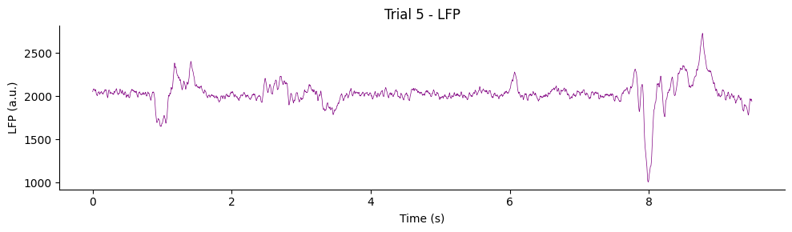

```python
# Check for LFP signal in processing module
if 'ecephys' in nwbfile.processing and 'LFP' in nwbfile.processing['ecephys'].data_interfaces:
    lfp_ts = nwbfile.processing['ecephys']['LFP']
    print(f"LFP signal available: {lfp_ts.data.shape[0]} samples")
    print(f"Units: {lfp_ts.unit}")
    print(f"Description: {lfp_ts.description}")

    # Plot LFP for a single trial
    # Note: Data are uncalibrated A/D converter values (centered ~2048), not volts
    trial_idx = 5
    trial = trials_df.iloc[trial_idx]
    t_start, t_stop = trial['start_time'], trial['stop_time']

    lfp_data = lfp_ts.data[:]
    lfp_timestamps = lfp_ts.timestamps[:]
    mask = (lfp_timestamps >= t_start) & (lfp_timestamps <= t_stop)

    fig, ax = plt.subplots(figsize=(10, 3))
    ax.plot(lfp_timestamps[mask] - t_start, lfp_data[mask], 'purple', linewidth=0.5)
    ax.set_xlabel('Time (s)')
    ax.set_ylabel('LFP (a.u.)')
    ax.set_title(f'Trial {trial_idx} - LFP')
    ax.spines['top'].set_visible(False)
    ax.spines['right'].set_visible(False)
    plt.tight_layout()
    plt.show()
else:
    print("No LFP signal in this session.")
```

## Antidromic Stimulation Raw Waveforms

In addition to the classification results in the units table, the raw antidromic stimulation data is available in the `AntidromicSweepsIntervals` table. Each row represents one 50ms sweep containing both the neural response and stimulation current waveforms.

| Column | Description | Values |
| --- | --- | --- |
| `start_time` | Sweep start time (25ms before stimulation) | seconds |
| `stop_time` | Sweep end time (25ms after stimulation) | seconds |
| `stimulation_onset_time` | Time of stimulation pulse delivery (t=0 in sweep) | seconds |
| `unit_name` | Unit number from source filename | `"1"` or `"2"` |
| `location` | Stimulation site | `"Striatum"`, `"Peduncle"`, `"Thalamus"` |
| `stimulation_protocol` | Test type performed | `"Collision"`, `"FrequencyFollowing"`, `"Orthodromic"` |
| `sweep_number` | Sweep index within the stimulation series | integer |
| `response` | Reference to neural voltage ElectricalSeries | object reference |
| `stimulation` | Reference to stimulation current TimeSeries | object reference |

**Protocol types explained:**

- **Collision**: Tests whether a spontaneous spike traveling down the axon blocks the antidromic spike - the gold-standard verification for antidromic activation
- **FrequencyFollowing**: Tests whether the neuron can follow high-frequency stimulation (>200 Hz) with consistent latency - verifies direct axonal activation vs synaptic
- **Orthodromic**: Control stimulation that activates the neuron through synaptic pathways (sub-threshold for antidromic)

**Note:** Not all sessions include antidromic stimulation data. Check if the intervals table exists before accessing.

```python
# Check if antidromic sweeps data exists and explore the table
if "AntidromicSweepsIntervals" in nwbfile.intervals:
    sweeps_df = nwbfile.intervals["AntidromicSweepsIntervals"].to_dataframe()
    print(f"Antidromic sweeps available: {len(sweeps_df)} sweeps")
    print(f"\nSweeps by stimulation location:")
    print(sweeps_df['location'].value_counts())
    print(f"\nSweeps by protocol type:")
    print(sweeps_df['stimulation_protocol'].value_counts())
else:
    print("No antidromic sweeps data in this session.")
```

```
Antidromic sweeps available: 62 sweeps

Sweeps by stimulation location:
location
Peduncle    62
Name: count, dtype: int64

Sweeps by protocol type:
stimulation_protocol
Collision             49
FrequencyFollowing    13
Name: count, dtype: int64
```

```python
# Preview the sweeps table structure
if "AntidromicSweepsIntervals" in nwbfile.intervals:
    display_columns = ['unit_name', 'location', 'stimulation_protocol', 'sweep_number',
                       'stimulation_onset_time']
    sweeps_df[display_columns].head(10)
```

### Accessing Raw Antidromic Waveforms

Each sweep contains two linked time series:

- **response**: Neural voltage recording from the M1 electrode (in volts)
- **stimulation**: Stimulation current delivered to the target site (in amperes)

The sweeps are 50ms long (1000 samples at 20kHz), centered on the stimulation pulse. To extract waveforms aligned to stimulation onset:

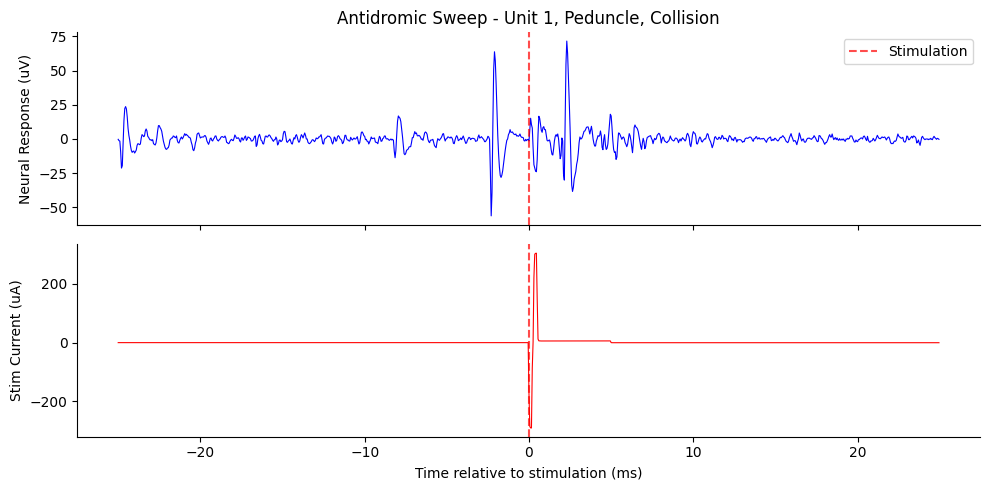

```
Sweep metadata:
  Stimulation site: Peduncle
  Protocol: Collision
  Sampling rate: 20000.0 Hz
```

```python
# Extract and plot a single antidromic sweep
if "AntidromicSweepsIntervals" in nwbfile.intervals:
    # Get the first sweep
    sweep = sweeps_df.iloc[0]

    # Access the response and stimulation data through TimeSeriesReference
    # Each reference is a tuple: (idx_start, count, timeseries)
    response_ref = sweep['response']
    index_start, count, response_series = response_ref
    response_data = response_series.data[index_start:index_start + count].flatten() * response_series.conversion * 1e6  # uV

    stim_ref = sweep['stimulation']
    index_start_s, count_s, stim_series = stim_ref
    stim_data = stim_series.data[index_start_s:index_start_s + count_s].flatten() * stim_series.conversion * 1e6  # uA

    # Create time axis relative to stimulation onset
    # Data starts 25ms before stimulation (t=0 is at sample 500 for 20kHz)
    sampling_rate = response_series.rate
    time_ms = (np.arange(count) / sampling_rate - 0.025) * 1000  # Time in ms relative to stim

    # Plot
    fig, axes = plt.subplots(2, 1, figsize=(10, 5), sharex=True)

    axes[0].plot(time_ms, response_data, 'b-', linewidth=0.8)
    axes[0].axvline(0, color='red', linestyle='--', alpha=0.7, label='Stimulation')
    axes[0].set_ylabel('Neural Response (uV)')
    axes[0].set_title(f"Antidromic Sweep - Unit {sweep['unit_name']}, {sweep['location']}, {sweep['stimulation_protocol']}")
    axes[0].legend(loc='upper right')
    axes[0].spines['top'].set_visible(False)
    axes[0].spines['right'].set_visible(False)

    axes[1].plot(time_ms, stim_data, 'r-', linewidth=0.8)
    axes[1].axvline(0, color='red', linestyle='--', alpha=0.7)
    axes[1].set_ylabel('Stim Current (uA)')
    axes[1].set_xlabel('Time relative to stimulation (ms)')
    axes[1].spines['top'].set_visible(False)
    axes[1].spines['right'].set_visible(False)

    plt.tight_layout()
    plt.show()

    print(f"\nSweep metadata:")
    print(f"  Stimulation site: {sweep['location']}")
    print(f"  Protocol: {sweep['stimulation_protocol']}")
    print(f"  Sampling rate: {sampling_rate} Hz")
```

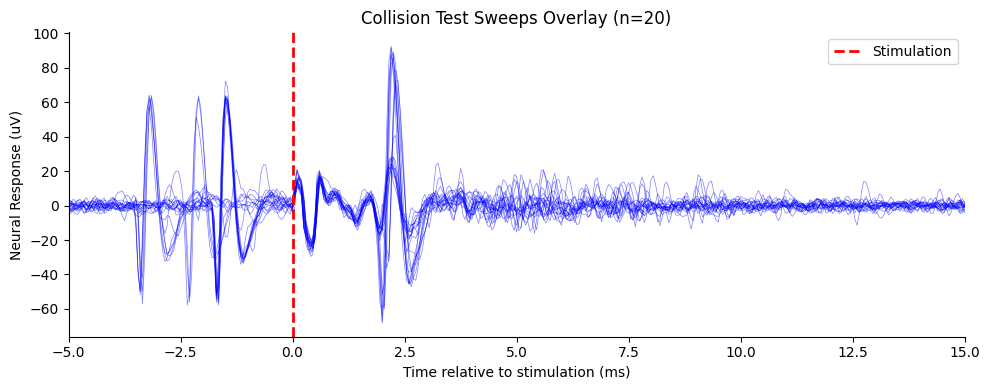

```python
# Overlay multiple collision test sweeps to visualize response consistency
if "AntidromicSweepsIntervals" in nwbfile.intervals:
    # Filter to collision test sweeps only
    collision_sweeps = sweeps_df[sweeps_df['stimulation_protocol'] == 'Collision']

    if len(collision_sweeps) > 0:
        fig, ax = plt.subplots(figsize=(10, 4))

        # Plot first 20 sweeps (or all if fewer)
        n_to_plot = min(20, len(collision_sweeps))

        for i in range(n_to_plot):
            sweep = collision_sweeps.iloc[i]

            # Access data through TimeSeriesReference
            response_ref = sweep['response']
            index_start, count, response_series = response_ref
            response_data = response_series.data[index_start:index_start + count].flatten() * response_series.conversion * 1e6

            sampling_rate = response_series.rate
            time_ms = (np.arange(count) / sampling_rate - 0.025) * 1000

            ax.plot(time_ms, response_data, 'b-', linewidth=0.5, alpha=0.5)

        ax.axvline(0, color='red', linestyle='--', linewidth=2, label='Stimulation')
        ax.set_xlabel('Time relative to stimulation (ms)')
        ax.set_ylabel('Neural Response (uV)')
        ax.set_title(f'Collision Test Sweeps Overlay (n={n_to_plot})')
        ax.legend(loc='upper right')
        ax.set_xlim(-5, 15)  # Focus on the response window
        ax.spines['top'].set_visible(False)
        ax.spines['right'].set_visible(False)

        plt.tight_layout()
        plt.show()

        # Get the antidromic latency from the units table for comparison
        unit_name = collision_sweeps.iloc[0]['unit_name']
        unit_row = units_df[units_df['unit_name'] == unit_name]
        if len(unit_row) > 0:
            latency = unit_row['antidromic_latency_ms'].values[0]
            if latency == latency:  # Check for NaN (NaN != NaN is True)
                print(f"Expected antidromic response at {latency:.2f} ms (from units table)")
    else:
        print("No collision test sweeps found in this session.")
```

### Stimulation Electrodes Table

The `StimulationElectrodesTable` in the `antidromic_identification` processing module documents the chronically implanted electrodes used for antidromic testing:

[output not shown]

These are distinct from the recording microelectrode in the electrodes table - they are macroelectrodes surgically implanted at fixed locations for stimulation, not recording.

```python
# Access the stimulation electrodes table
if "antidromic_identification" in nwbfile.processing:
    antidromic_module = nwbfile.processing["antidromic_identification"]
    if "StimulationElectrodesTable" in antidromic_module.data_interfaces:
        stim_electrodes = antidromic_module["StimulationElectrodesTable"].to_dataframe()
        display(stim_electrodes)
    else:
        print("StimulationElectrodesTable not found in this session.")
else:
    print("No antidromic_identification processing module in this session.")
```

| id | location | device_name | n_contacts | notes |
| --- | --- | --- | --- | --- |
| 0 | Cerebral peduncle (pre-pontine) | DeviceMicrowirePeduncleStimulation | 2 | Pre-pontine peduncle (2 contacts). For PTN ide... |
| 1 | Putamen (posterolateral) | DeviceMicrowirePutamenStimulation1 | 3 | Electrode 1 of 2, posterolateral putamen (3 co... |
| 2 | Putamen (posterolateral) | DeviceMicrowirePutamenStimulation2 | 2 | Electrode 2 of 2, posterolateral putamen (2 co... |
| 3 | Ventrolateral thalamus | DeviceMicrowireThalamicStimulation | 1 | VL thalamus (1 contact) for thalamocortical pr... |